# AIPD - Diagnostics and Imaging Results

# libraries

```r
library(tidyverse)
library(dplyr)
library(ggplot2)
```

# preprocessing

```r
# load data from CATMA
CATMA <- read.csv(file = "CATMA_results.csv", sep = ",")
head(CATMA)
```

|  | Group | Total | FAZ...Sind.Algorithmen.die.besseren.Ã.rzte..D_28763721.637D.444B.ADB8.FF278C9DB23F. | FAZ...Sind.Algorithmen.die.besseren.Ã.rzte.Default.Annotations..C_2DAAB5CA.1118.4703.AE3E.77F03CBA5077. | Im.Kampf.gegen.Krebs.sind.wir.mitten.in.einer.explosiven.Entwicklung..D_2DE464EE.FF9F.4C8A.A6E6.8763FB6B98F8. | Im.Kampf.gegen.Krebs.sind.wir.mitten.in.einer.explosiven.Entwicklung.Default.Annotations..C_3283F2FD.8065.4F41.B2CE.7051F928F5DE. | Deutschlandfunk.Kultur...KI.in.der.Medizin..D_2E5B6E46.7AC2.4F96.83C3.6DC4D8F0F7AE. | Deutschlandfunk.Kultur...KI.in.der.Medizin.Default.Annotations..C_D3153C5D.A3ED.4E3A.A96D.07FAEEB7F654. | Ã.rzteblatt...KÃ.nstliche.Intelligenz.soll.MRT.Auswertung.beschleunigen..D_3878BC46.DE40.460C.AE96.88E9937E0FE0. | Ã.rzteblatt...KÃ.nstliche.Intelligenz.soll.MRT.Auswertung.beschleunigen.Default.Annotations..C_A4E56661.D66B.4EE9.9ADF.815BC159D2A3. | Deutschlandfunk...Wenn.Computer.besser.diagnostizieren.als.Menschen..D_50B0166F.0307.469D.93D8.8A02818C2001. | Deutschlandfunk...Wenn.Computer.besser.diagnostizieren.als.Menschen.Default.Annotations..C_8C10CDEB.7CE4.41B4.B23C.3E3F494B3B10. | Deutschlandfunk.Kultur...Kann.KI.den.Krebs.besiegen..D_551EF922.7A15.48AA.A448.61D35E420341. | Deutschlandfunk.Kultur...Kann.KI.den.Krebs.besiegen.Default.Annotations..C_B65E3E18.3FD4.4688.B5F3.FCFF523DD9EB. | SWR.Wissen...KÃ.nstliche.Intelligenz.im.Kampf.gegen.Krebs..D_5E9CFFAA.5796.40AD.B298.E851D853878E. | SWR.Wissen...KÃ.nstliche.Intelligenz.im.Kampf.gegen.Krebs.Default.Annotations..C_AD2AD8F6.8C70.4171.812B.397311956434. | TK.Manager.Deutschland.steht.kurz.vor.einer.Medizin.Revolution..D_622F7E4E.DB15.44D0.BCBE.173325BE07B1. | TK.Manager.Deutschland.steht.kurz.vor.einer.Medizin.Revolution.Default.Annotations..C_E570D2CB.6B13.4D18.855A.DD4DC790A856. | Zeit...Wenn.Computer.RÃ.ntgenbilder.auswerten..D_661E6C57.3231.458F.B4F1.7F9DB5AAEE25. | Zeit...Wenn.Computer.RÃ.ntgenbilder.auswerten.Default.Annotations..C_8CBE585D.52ED.44EE.A984.BF6BFEB8E62B. | Zeit...Dr.KI.hat.nun.Zeit.fÃ.r.Sie..D_6AA35A82.E135.47DD.AB7A.008B67D15B0E. | Zeit...Dr.KI.hat.nun.Zeit.fÃ.r.Sie.Default.Annotations..C_402EE761.2697.4E30.B05F.04046F1995FA. | rnd...KI.im.Krankenhaus..D_75DF8484.5689.482A.A4C4.06D81ADD649A. | rnd...KI.im.Krankenhaus.Default.Annotations..C_4AB9B1D6.4E13.437B.8257.FCFE0CB2359C. | DW...KI.in.der.Medizin.Der.Computer.weiß..was.dir.fehlt..D_782539D2.C020.4FCA.B096.85E1384F4FDC. | DW...KI.in.der.Medizin.Der.Computer.weiß..was.dir.fehlt.Default.Annotations..C_62D98048.BCAD.4808.AEEE.246654551355. | KÃ.nstliche.Intelligenz.hilft..Schizophrenie.besser.zu.verstehen..D_846F9002.59FC.463A.9AE0.0CA686B9D867. | KÃ.nstliche.Intelligenz.hilft..Schizophrenie.besser.zu.verstehen.Default.Annotations..C_74759368.F765.46C3.BEDD.E6DD50E848BC. | Studie.zeigt.großes.Potenzial.in.KI.Kooperation..D_869C3658.45CB.4BF1.A748.32D3C2347443. | … |
| --- | --- | --- | --- | --- | --- | --- | --- | --- | --- | --- | --- | --- | --- | --- | --- | --- | --- | --- | --- | --- | --- | --- | --- | --- | --- | --- | --- | --- | --- | --- |
| 1 | /2017 | 3 | NA | NA | NA | NA | NA | NA | NA | NA | NA | NA | NA | NA | NA | NA | NA | NA | NA | NA | NA | NA | NA | NA | NA | NA | NA | NA | NA | … |
| 2 | /2018 | 4 | NA | NA | NA | NA | NA | NA | NA | NA | NA | NA | NA | NA | NA | NA | NA | NA | NA | NA | 1 | 1 | NA | NA | 1 | 1 | NA | NA | NA | … |
| 3 | /2019 | 8 | NA | NA | 1 | 1 | NA | NA | NA | NA | NA | NA | NA | NA | NA | NA | 1 | 1 | 1 | 1 | NA | NA | NA | NA | NA | NA | 1 | 1 | NA | … |
| 4 | /2020 | 9 | 1 | 1 | NA | NA | 1 | 1 | 1 | 1 | 1 | 1 | 1 | 1 | 1 | 1 | NA | NA | NA | NA | NA | NA | 1 | 1 | NA | NA | NA | NA | 1 | … |
| 5 | /Algorithm | 48 | 9 | 9 | 2 | 2 | 1 | 1 | NA | NA | 9 | 9 | NA | NA | 6 | 6 | NA | NA | NA | NA | NA | NA | NA | NA | NA | NA | NA | NA | NA | … |
| 6 | /Application | 11 | NA | NA | NA | NA | 1 | 1 | NA | NA | NA | NA | NA | NA | NA | NA | 2 | 2 | NA | NA | NA | NA | NA | NA | NA | NA | NA | NA | 1 | … |

```r
CATMA <- CATMA %>% rename("Tags" = 1)

# delete every second column (every article has 2 columns with the exact same content)
df <- CATMA %>% select(everything()[c(TRUE, FALSE)])
df <- df[-1]

data <- cbind(CATMA[1:2],df)
# replace article names with numbers for better overview
# (names are not relevant for our quantitative analyses)
columns <- c("Tags", "Total", c(1:24))
names(data) <- columns
data
```

| Tags | Total | 1 | 2 | 3 | 4 | 5 | 6 | 7 | 8 | 9 | 10 | 11 | 12 | 13 | 14 | 15 | 16 | 17 | 18 | 19 | 20 | 21 | 22 | 23 | 24 |
| --- | --- | --- | --- | --- | --- | --- | --- | --- | --- | --- | --- | --- | --- | --- | --- | --- | --- | --- | --- | --- | --- | --- | --- | --- | --- |
| /2017 | 3 | NA | NA | NA | NA | NA | NA | NA | NA | NA | NA | NA | NA | NA | NA | NA | NA | 1 | 1 | NA | NA | NA | NA | 1 | NA |
| /2018 | 4 | NA | NA | NA | NA | NA | NA | NA | NA | NA | 1 | NA | 1 | NA | NA | NA | 1 | NA | NA | NA | 1 | NA | NA | NA | NA |
| /2019 | 8 | NA | 1 | NA | NA | NA | NA | NA | 1 | 1 | NA | NA | NA | 1 | NA | 1 | NA | NA | NA | NA | NA | 1 | 1 | NA | 1 |
| /2020 | 9 | 1 | NA | 1 | 1 | 1 | 1 | 1 | NA | NA | NA | 1 | NA | NA | 1 | NA | NA | NA | NA | 1 | NA | NA | NA | NA | NA |
| /Algorithm | 48 | 9 | 2 | 1 | NA | 9 | NA | 6 | NA | NA | NA | NA | NA | NA | NA | 1 | NA | 4 | NA | NA | 1 | NA | 7 | NA | 8 |
| /Application | 11 | NA | NA | 1 | NA | NA | NA | NA | 2 | NA | NA | NA | NA | NA | 1 | NA | NA | NA | 1 | NA | 2 | NA | 4 | NA | NA |
| /Big Data | 5 | NA | NA | NA | NA | 2 | NA | NA | NA | NA | NA | NA | 1 | NA | NA | NA | NA | NA | NA | NA | 2 | NA | NA | NA | NA |
| /Brain | 3 | NA | NA | 3 | NA | NA | NA | NA | NA | NA | NA | NA | NA | NA | NA | NA | NA | NA | NA | NA | NA | NA | NA | NA | NA |
| /Chatbot | 18 | NA | NA | NA | NA | NA | NA | NA | NA | NA | NA | NA | 2 | NA | NA | NA | NA | NA | NA | NA | 16 | NA | NA | NA | NA |
| /Cloud | 3 | NA | NA | 2 | NA | 1 | NA | NA | NA | NA | NA | NA | NA | NA | NA | NA | NA | NA | NA | NA | NA | NA | NA | NA | NA |

[output cut: 34 more lines]

```r
# extract year data
year_data <- data[1:4,]
year_data
```

|  | Tags | Total | 1 | 2 | 3 | 4 | 5 | 6 | 7 | 8 | 9 | 10 | 11 | 12 | 13 | 14 | 15 | 16 | 17 | 18 | 19 | 20 | 21 | 22 | 23 | 24 |
| --- | --- | --- | --- | --- | --- | --- | --- | --- | --- | --- | --- | --- | --- | --- | --- | --- | --- | --- | --- | --- | --- | --- | --- | --- | --- | --- |
| 1 | /2017 | 3 | NA | NA | NA | NA | NA | NA | NA | NA | NA | NA | NA | NA | NA | NA | NA | NA | 1 | 1 | NA | NA | NA | NA | 1 | NA |
| 2 | /2018 | 4 | NA | NA | NA | NA | NA | NA | NA | NA | NA | 1 | NA | 1 | NA | NA | NA | 1 | NA | NA | NA | 1 | NA | NA | NA | NA |
| 3 | /2019 | 8 | NA | 1 | NA | NA | NA | NA | NA | 1 | 1 | NA | NA | NA | 1 | NA | 1 | NA | NA | NA | NA | NA | 1 | 1 | NA | 1 |
| 4 | /2020 | 9 | 1 | NA | 1 | 1 | 1 | 1 | 1 | NA | NA | NA | 1 | NA | NA | 1 | NA | NA | NA | NA | 1 | NA | NA | NA | NA | NA |

```r
# extract synonym data
synonym_data <- data[c(5:10,12:14,16:19,21:24),]
synonym_data
```

|  | Tags | Total | 1 | 2 | 3 | 4 | 5 | 6 | 7 | 8 | 9 | 10 | 11 | 12 | 13 | 14 | 15 | 16 | 17 | 18 | 19 | 20 | 21 | 22 | 23 | 24 |
| --- | --- | --- | --- | --- | --- | --- | --- | --- | --- | --- | --- | --- | --- | --- | --- | --- | --- | --- | --- | --- | --- | --- | --- | --- | --- | --- |
| 5 | /Algorithm | 48 | 9 | 2 | 1 | NA | 9 | NA | 6 | NA | NA | NA | NA | NA | NA | NA | 1 | NA | 4 | NA | NA | 1 | NA | 7 | NA | 8 |
| 6 | /Application | 11 | NA | NA | 1 | NA | NA | NA | NA | 2 | NA | NA | NA | NA | NA | 1 | NA | NA | NA | 1 | NA | 2 | NA | 4 | NA | NA |
| 7 | /Big Data | 5 | NA | NA | NA | NA | 2 | NA | NA | NA | NA | NA | NA | 1 | NA | NA | NA | NA | NA | NA | NA | 2 | NA | NA | NA | NA |
| 8 | /Brain | 3 | NA | NA | 3 | NA | NA | NA | NA | NA | NA | NA | NA | NA | NA | NA | NA | NA | NA | NA | NA | NA | NA | NA | NA | NA |
| 9 | /Chatbot | 18 | NA | NA | NA | NA | NA | NA | NA | NA | NA | NA | NA | 2 | NA | NA | NA | NA | NA | NA | NA | 16 | NA | NA | NA | NA |
| 10 | /Cloud | 3 | NA | NA | 2 | NA | 1 | NA | NA | NA | NA | NA | NA | NA | NA | NA | NA | NA | NA | NA | NA | NA | NA | NA | NA | NA |
| 12 | /Computer | 69 | NA | 8 | NA | NA | 10 | 3 | 3 | NA | 1 | 3 | 1 | 3 | NA | NA | 9 | NA | 6 | NA | NA | NA | 1 | 1 | 1 | 19 |
| 13 | /Deep Learning / Networks | 20 | 7 | NA | NA | NA | NA | NA | 1 | NA | 1 | 2 | 1 | NA | NA | NA | NA | NA | NA | 1 | NA | 2 | 2 | 2 | 1 | NA |
| 14 | /Digitalization | 5 | NA | NA | NA | NA | 3 | 1 | NA | 1 | NA | NA | NA | NA | NA | NA | NA | NA | NA | NA | NA | NA | NA | NA | NA | NA |
| 16 | /Machine | 21 | NA | 1 | 6 | NA | NA | 1 | 1 | NA | NA | 2 | NA | 1 | NA | NA | NA | NA | 1 | NA | 2 | 1 | NA | 3 | 2 | NA |

[output cut: 7 more lines]

```r
# extract article type data
article_type_data <- data[c(11,15,20),]
article_type_data
```

|  | Tags | Total | 1 | 2 | 3 | 4 | 5 | 6 | 7 | 8 | 9 | 10 | 11 | 12 | 13 | 14 | 15 | 16 | 17 | 18 | 19 | 20 | 21 | 22 | 23 | 24 |
| --- | --- | --- | --- | --- | --- | --- | --- | --- | --- | --- | --- | --- | --- | --- | --- | --- | --- | --- | --- | --- | --- | --- | --- | --- | --- | --- |
| 11 | /Commentary | 1 | NA | NA | NA | NA | NA | NA | NA | NA | NA | NA | NA | NA | NA | NA | NA | NA | NA | NA | NA | NA | NA | NA | 1 | NA |
| 15 | /Interview | 4 | NA | 1 | 1 | NA | NA | NA | NA | 1 | NA | NA | NA | NA | NA | NA | NA | NA | NA | NA | NA | NA | NA | NA | NA | 1 |
| 20 | /Report | 19 | 1 | NA | NA | 1 | 1 | 1 | 1 | NA | 1 | 1 | 1 | 1 | 1 | 1 | 1 | 1 | 1 | 1 | 1 | 1 | 1 | 1 | NA | NA |

```r
# extract illness data
illness_data <- data[c(25,31,35),]
illness_data
```

|  | Tags | Total | 1 | 2 | 3 | 4 | 5 | 6 | 7 | 8 | 9 | 10 | 11 | 12 | 13 | 14 | 15 | 16 | 17 | 18 | 19 | 20 | 21 | 22 | 23 | 24 |
| --- | --- | --- | --- | --- | --- | --- | --- | --- | --- | --- | --- | --- | --- | --- | --- | --- | --- | --- | --- | --- | --- | --- | --- | --- | --- | --- |
| 25 | /cancer | 38 | 2 | 2 | NA | NA | 4 | 1 | 2 | NA | 1 | 2 | 4 | 2 | NA | 1 | 6 | 1 | 4 | NA | 1 | NA | 1 | 2 | 1 | 1 |
| 31 | /non-cancer | 23 | 1 | NA | NA | 1 | 1 | 1 | 1 | NA | 3 | 1 | NA | 4 | NA | NA | NA | NA | NA | NA | NA | 1 | 1 | 4 | 3 | 1 |
| 35 | /psychological | 7 | NA | NA | NA | NA | NA | 1 | NA | NA | NA | NA | NA | 1 | 1 | NA | NA | NA | NA | 3 | NA | 1 | NA | NA | NA | NA |

```r
# extract sentiment data
sentiment_data <- data[c(34,30,26),]
sentiment_data
```

|  | Tags | Total | 1 | 2 | 3 | 4 | 5 | 6 | 7 | 8 | 9 | 10 | 11 | 12 | 13 | 14 | 15 | 16 | 17 | 18 | 19 | 20 | 21 | 22 | 23 | 24 |
| --- | --- | --- | --- | --- | --- | --- | --- | --- | --- | --- | --- | --- | --- | --- | --- | --- | --- | --- | --- | --- | --- | --- | --- | --- | --- | --- |
| 34 | /pro AI | 126 | NA | 7 | 6 | NA | 4 | 11 | 4 | 9 | 1 | 3 | 10 | 7 | 2 | 3 | 7 | 2 | 4 | 4 | 7 | 11 | 4 | 14 | 2 | 4 |
| 30 | /neutral | 78 | 1 | 7 | 1 | 1 | 2 | NA | 6 | 3 | 1 | 4 | 6 | 3 | 4 | 5 | NA | NA | NA | NA | 4 | 13 | 2 | 10 | 1 | 4 |
| 26 | /contra AI | 35 | 3 | 2 | NA | NA | 2 | NA | 1 | 1 | 1 | 3 | 1 | 1 | NA | NA | 1 | NA | NA | NA | 1 | 3 | NA | 3 | NA | 12 |

```r
# extract personal impression data
personal_impression_data <- data[c(33,29,28),]
personal_impression_data
```

|  | Tags | Total | 1 | 2 | 3 | 4 | 5 | 6 | 7 | 8 | 9 | 10 | 11 | 12 | 13 | 14 | 15 | 16 | 17 | 18 | 19 | 20 | 21 | 22 | 23 | 24 |
| --- | --- | --- | --- | --- | --- | --- | --- | --- | --- | --- | --- | --- | --- | --- | --- | --- | --- | --- | --- | --- | --- | --- | --- | --- | --- | --- |
| 33 | /positive | 13 | NA | 1 | NA | NA | NA | 1 | NA | 1 | NA | NA | 1 | 1 | 1 | 1 | 1 | 1 | 1 | NA | 1 | 1 | NA | NA | 1 | NA |
| 29 | /neither positive nor negative | 8 | NA | NA | 1 | 1 | 1 | NA | 1 | NA | 1 | NA | NA | NA | NA | NA | NA | NA | NA | 1 | NA | NA | 1 | 1 | NA | NA |
| 28 | /negative | 3 | 1 | NA | NA | NA | NA | NA | NA | NA | NA | 1 | NA | NA | NA | NA | NA | NA | NA | NA | NA | NA | NA | NA | NA | 1 |

```r
# extract article specialization data
specialization_data <- data[c(36:38,41:43),]
specialization_data
```

|  | Tags | Total | 1 | 2 | 3 | 4 | 5 | 6 | 7 | 8 | 9 | 10 | 11 | 12 | 13 | 14 | 15 | 16 | 17 | 18 | 19 | 20 | 21 | 22 | 23 | 24 |
| --- | --- | --- | --- | --- | --- | --- | --- | --- | --- | --- | --- | --- | --- | --- | --- | --- | --- | --- | --- | --- | --- | --- | --- | --- | --- | --- |
| 36 | /specialized | 7 | NA | NA | NA | 1 | NA | NA | NA | NA | NA | NA | NA | NA | 1 | 1 | NA | 1 | 1 | 1 | NA | 1 | NA | NA | NA | NA |
| 37 | /specialized/expert (author)/medicine | 1 | NA | NA | NA | NA | NA | NA | NA | NA | NA | NA | NA | NA | NA | NA | NA | NA | NA | NA | NA | 1 | NA | NA | NA | NA |
| 38 | /specialized/non-expert (author) | 1 | NA | NA | NA | NA | NA | NA | NA | NA | NA | NA | NA | NA | NA | NA | NA | NA | NA | 1 | NA | NA | NA | NA | NA | NA |
| 41 | /unspecialized | 17 | 1 | 1 | 1 | NA | 1 | 1 | 1 | 1 | 1 | 1 | 1 | 1 | NA | NA | 1 | NA | NA | NA | 1 | NA | 1 | 1 | 1 | 1 |
| 42 | /unspecialized/expert (author)/medicine | 3 | NA | 1 | NA | NA | NA | NA | NA | NA | NA | NA | NA | NA | NA | NA | 1 | NA | NA | NA | NA | NA | NA | NA | NA | 1 |
| 43 | /unspecialized/non-expert (author) | 11 | 1 | NA | 1 | NA | 1 | 1 | 1 | 1 | NA | 1 | NA | 1 | NA | NA | NA | NA | NA | NA | 1 | NA | NA | 1 | 1 | NA |

```r
# from that, extract author expertise data
expert_data <- specialization_data[c(2,3,5,6),]
expert_data
```

|  | Tags | Total | 1 | 2 | 3 | 4 | 5 | 6 | 7 | 8 | 9 | 10 | 11 | 12 | 13 | 14 | 15 | 16 | 17 | 18 | 19 | 20 | 21 | 22 | 23 | 24 |
| --- | --- | --- | --- | --- | --- | --- | --- | --- | --- | --- | --- | --- | --- | --- | --- | --- | --- | --- | --- | --- | --- | --- | --- | --- | --- | --- |
| 37 | /specialized/expert (author)/medicine | 1 | NA | NA | NA | NA | NA | NA | NA | NA | NA | NA | NA | NA | NA | NA | NA | NA | NA | NA | NA | 1 | NA | NA | NA | NA |
| 38 | /specialized/non-expert (author) | 1 | NA | NA | NA | NA | NA | NA | NA | NA | NA | NA | NA | NA | NA | NA | NA | NA | NA | 1 | NA | NA | NA | NA | NA | NA |
| 42 | /unspecialized/expert (author)/medicine | 3 | NA | 1 | NA | NA | NA | NA | NA | NA | NA | NA | NA | NA | NA | NA | 1 | NA | NA | NA | NA | NA | NA | NA | NA | 1 |
| 43 | /unspecialized/non-expert (author) | 11 | 1 | NA | 1 | NA | 1 | 1 | 1 | 1 | NA | 1 | NA | 1 | NA | NA | NA | NA | NA | NA | 1 | NA | NA | 1 | 1 | NA |

```r
# extract SWOT data
SWOT_data <- data[c(39,44,32,40),]
SWOT_data
```

|  | Tags | Total | 1 | 2 | 3 | 4 | 5 | 6 | 7 | 8 | 9 | 10 | 11 | 12 | 13 | 14 | 15 | 16 | 17 | 18 | 19 | 20 | 21 | 22 | 23 | 24 |
| --- | --- | --- | --- | --- | --- | --- | --- | --- | --- | --- | --- | --- | --- | --- | --- | --- | --- | --- | --- | --- | --- | --- | --- | --- | --- | --- |
| 39 | /strength | 59 | NA | 1 | 2 | NA | 2 | 4 | 3 | 3 | 2 | 1 | 4 | 8 | NA | 1 | 2 | 3 | 3 | NA | 2 | 1 | 2 | 10 | 3 | 2 |
| 44 | /weakness | 60 | 2 | 5 | 1 | 1 | 3 | NA | 6 | 2 | 1 | 3 | 4 | NA | NA | 2 | 5 | NA | NA | NA | 5 | 2 | 2 | 4 | 2 | 10 |
| 32 | /opportunity | 112 | NA | 2 | 6 | 1 | 7 | 2 | 5 | 6 | 2 | 3 | 6 | 7 | 2 | 6 | 8 | NA | 3 | 2 | 9 | 10 | 9 | 14 | 1 | 1 |
| 40 | /threat | 26 | 1 | 1 | 3 | NA | 5 | NA | NA | 3 | NA | 1 | 1 | NA | NA | 2 | 2 | NA | NA | NA | NA | 2 | NA | 2 | 1 | 2 |

# article specialization

## article specialization total

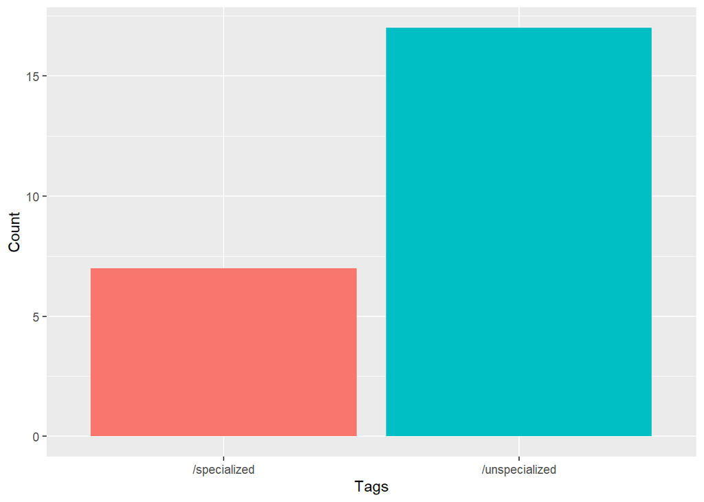

```r
specialized_unspecialized <- specialization_data[c(1,4),]

ggplot(specialized_unspecialized, aes(fill=Tags, y=Total, x=Tags)) +
    geom_bar(position="dodge", stat="identity") +
    labs(y = "Count") +
    theme(legend.position = "none")
```

In total, our sources are not evenly distributed over specialized and unspecialized articles.

## percentage of experts

```r
# clean up author expertise data, calculate the number of unknown authors
specialization <- tibble("Tags" = specialization_data$Tags,
                         "Article" = c(rep("specialized", 3), rep("unspecialized", 3)),
                         "Author" = c(rep(c("unknown","expert medicine", "non-expert"), 2)),
                         "Total" = c(as.integer(specialization_data$Total[1]-
                                                specialization_data$Total[2]-
                                                specialization_data$Total[3]),
                                     specialization_data$Total[2],
                                     specialization_data$Total[3],
                                     as.integer(specialization_data$Total[4]-
                                                specialization_data$Total[5]-
                                                specialization_data$Total[6]),
                                     specialization_data$Total[5],
                                     specialization_data$Total[6]))
specialization <- cbind(specialization, specialization_data[3:26])
specialization
```

|  | Tags | Article | Author | Total | 1 | 2 | 3 | 4 | 5 | 6 | 7 | 8 | 9 | 10 | 11 | 12 | 13 | 14 | 15 | 16 | 17 | 18 | 19 | 20 | 21 | 22 | 23 | 24 |
| --- | --- | --- | --- | --- | --- | --- | --- | --- | --- | --- | --- | --- | --- | --- | --- | --- | --- | --- | --- | --- | --- | --- | --- | --- | --- | --- | --- | --- |
| 36 | /specialized | specialized | unknown | 5 | NA | NA | NA | 1 | NA | NA | NA | NA | NA | NA | NA | NA | 1 | 1 | NA | 1 | 1 | 1 | NA | 1 | NA | NA | NA | NA |
| 37 | /specialized/expert (author)/medicine | specialized | expert medicine | 1 | NA | NA | NA | NA | NA | NA | NA | NA | NA | NA | NA | NA | NA | NA | NA | NA | NA | NA | NA | 1 | NA | NA | NA | NA |
| 38 | /specialized/non-expert (author) | specialized | non-expert | 1 | NA | NA | NA | NA | NA | NA | NA | NA | NA | NA | NA | NA | NA | NA | NA | NA | NA | 1 | NA | NA | NA | NA | NA | NA |
| 41 | /unspecialized | unspecialized | unknown | 3 | 1 | 1 | 1 | NA | 1 | 1 | 1 | 1 | 1 | 1 | 1 | 1 | NA | NA | 1 | NA | NA | NA | 1 | NA | 1 | 1 | 1 | 1 |
| 42 | /unspecialized/expert (author)/medicine | unspecialized | expert medicine | 3 | NA | 1 | NA | NA | NA | NA | NA | NA | NA | NA | NA | NA | NA | NA | 1 | NA | NA | NA | NA | NA | NA | NA | NA | 1 |
| 43 | /unspecialized/non-expert (author) | unspecialized | non-expert | 11 | 1 | NA | 1 | NA | 1 | 1 | 1 | 1 | NA | 1 | NA | 1 | NA | NA | NA | NA | NA | NA | 1 | NA | NA | 1 | 1 | NA |

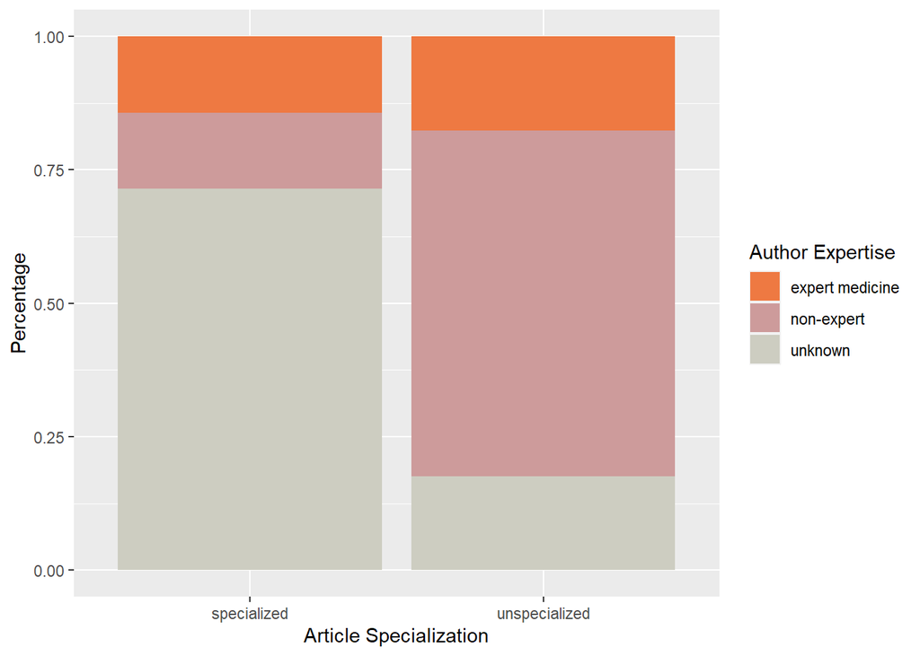

```r
ggplot(specialization, aes(fill=Author, y=Total, x=Article)) +
    geom_bar(position="fill", stat="identity") +
    labs(y = "Percentage", x = "Article Specialization",
         fill = "Author Expertise") +
    scale_fill_manual(values=c("sienna2", "rosybrown3", "ivory3"))
```

For the majority of the specialized articles we could not find out the authors and therefore their expertise is unknown. In general, the number of articles written by non-experts is much higher than the number of articles written by medical experts.

# article type total

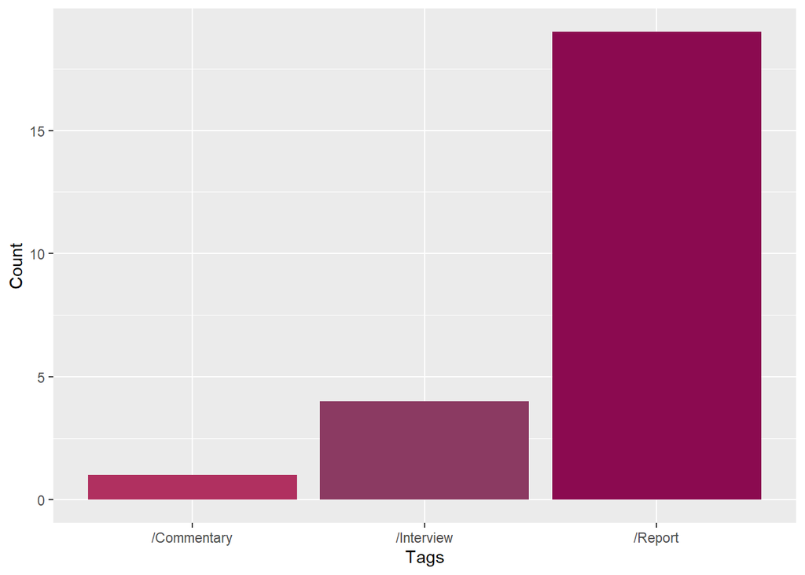

```r
ggplot(article_type_data, aes(fill=Tags, y=Total, x=Tags)) +
    geom_bar(position="dodge", stat="identity") +
    labs(y = "Count") +
    theme(legend.position = "none") +
    scale_fill_manual(values=c("maroon","hotpink4","deeppink4"))
```

The majority of our articles are reports and a few of them are interviews, while only one is a commentary.

# sentiment

## sentiment total

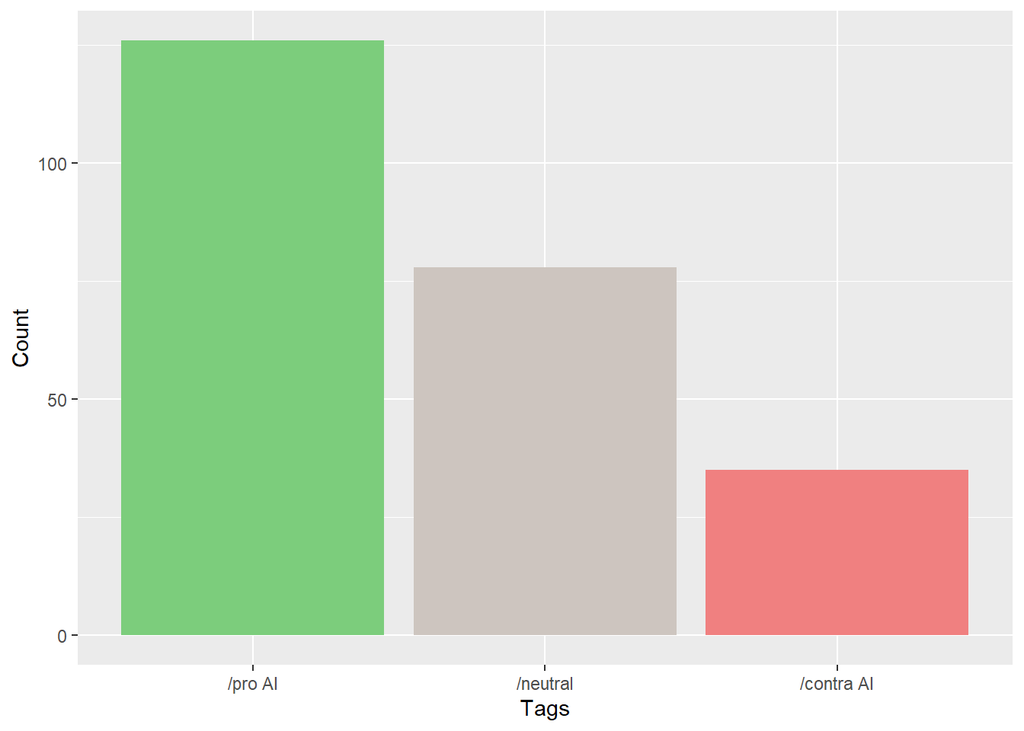

```r
ggplot(sentiment_data, aes(fill=factor(Tags,levels=c("/pro AI","/neutral","/contra AI")), y=Total, x=factor(Tags,levels=c("/pro AI","/neutral","/contra AI")))) +
    geom_bar(position="dodge", stat="identity") +
    labs(y = "Count", x = "Tags") +
    theme(legend.position = "none") +
    scale_fill_manual(values=c("palegreen3","seashell3","lightcoral"))
```

All in all, the sentiments in favor of AI outweigh both the neutral attitudes and the arguments against AI, with the latter being discussed least often.

## article specialization and percentage of sentiment

```r
# combine article specialization and sentiment data
specialization_sentiment <- rbind(specialization_data, sentiment_data)
specialization_sentiment
```

|  | Tags | Total | 1 | 2 | 3 | 4 | 5 | 6 | 7 | 8 | 9 | 10 | 11 | 12 | 13 | 14 | 15 | 16 | 17 | 18 | 19 | 20 | 21 | 22 | 23 | 24 |
| --- | --- | --- | --- | --- | --- | --- | --- | --- | --- | --- | --- | --- | --- | --- | --- | --- | --- | --- | --- | --- | --- | --- | --- | --- | --- | --- |
| 36 | /specialized | 7 | NA | NA | NA | 1 | NA | NA | NA | NA | NA | NA | NA | NA | 1 | 1 | NA | 1 | 1 | 1 | NA | 1 | NA | NA | NA | NA |
| 37 | /specialized/expert (author)/medicine | 1 | NA | NA | NA | NA | NA | NA | NA | NA | NA | NA | NA | NA | NA | NA | NA | NA | NA | NA | NA | 1 | NA | NA | NA | NA |
| 38 | /specialized/non-expert (author) | 1 | NA | NA | NA | NA | NA | NA | NA | NA | NA | NA | NA | NA | NA | NA | NA | NA | NA | 1 | NA | NA | NA | NA | NA | NA |
| 41 | /unspecialized | 17 | 1 | 1 | 1 | NA | 1 | 1 | 1 | 1 | 1 | 1 | 1 | 1 | NA | NA | 1 | NA | NA | NA | 1 | NA | 1 | 1 | 1 | 1 |
| 42 | /unspecialized/expert (author)/medicine | 3 | NA | 1 | NA | NA | NA | NA | NA | NA | NA | NA | NA | NA | NA | NA | 1 | NA | NA | NA | NA | NA | NA | NA | NA | 1 |
| 43 | /unspecialized/non-expert (author) | 11 | 1 | NA | 1 | NA | 1 | 1 | 1 | 1 | NA | 1 | NA | 1 | NA | NA | NA | NA | NA | NA | 1 | NA | NA | 1 | 1 | NA |
| 34 | /pro AI | 126 | NA | 7 | 6 | NA | 4 | 11 | 4 | 9 | 1 | 3 | 10 | 7 | 2 | 3 | 7 | 2 | 4 | 4 | 7 | 11 | 4 | 14 | 2 | 4 |
| 30 | /neutral | 78 | 1 | 7 | 1 | 1 | 2 | NA | 6 | 3 | 1 | 4 | 6 | 3 | 4 | 5 | NA | NA | NA | NA | 4 | 13 | 2 | 10 | 1 | 4 |
| 26 | /contra AI | 35 | 3 | 2 | NA | NA | 2 | NA | 1 | 1 | 1 | 3 | 1 | 1 | NA | NA | 1 | NA | NA | NA | 1 | 3 | NA | 3 | NA | 12 |

```r
# summarize articles and counts
specialization_sentiment <- specialization_sentiment %>%
  pivot_longer(3:26, names_to = "article", values_to = "count") %>%
  drop_na()
specialization_sentiment
```

| Tags | Total | article | count |
| --- | --- | --- | --- |
| /specialized | 7 | 4 | 1 |
| /specialized | 7 | 13 | 1 |
| /specialized | 7 | 14 | 1 |
| /specialized | 7 | 16 | 1 |
| /specialized | 7 | 17 | 1 |
| /specialized | 7 | 18 | 1 |
| /specialized | 7 | 20 | 1 |
| /specialized/expert (author)/medicine | 1 | 20 | 1 |
| /specialized/non-expert (author) | 1 | 18 | 1 |
| /unspecialized | 17 | 1 | 1 |

[output cut: 85 more lines]

```r
spec <- specialization_sentiment[1:40,]
sentim <- specialization_sentiment[41:95,]

# merge data based on the articles
specialization_sentiment <- merge.data.frame(spec[-2],sentim[-2],by="article")%>%
                            select(c(2,4,5)) %>%
                            group_by(Tags.x, Tags.y) %>%
                            summarise_each(list(sum = sum)) %>%
                            rename("Article_Specialization" = 1, "Sentiment" = 2, "Count" = 3)
specialization_sentiment
```

| Article_Specialization | Sentiment | Count |
| --- | --- | --- |
| /specialized | /contra AI | 3 |
| /specialized | /neutral | 23 |
| /specialized | /pro AI | 26 |
| /specialized/expert (author)/medicine | /contra AI | 3 |
| /specialized/expert (author)/medicine | /neutral | 13 |
| /specialized/expert (author)/medicine | /pro AI | 11 |
| /specialized/non-expert (author) | /pro AI | 4 |
| /unspecialized | /contra AI | 32 |
| /unspecialized | /neutral | 55 |
| /unspecialized | /pro AI | 100 |

[output cut: 6 more lines]

```r
# extract author expertise data
expert_sentiment <- specialization_sentiment[c(4:7,11:16),]
expert_sentiment$Article_Specialization <- c(rep("expert medicine",3),"non-expert",rep("expert medicine",3),rep("non-expert", 3))
expert_sentiment <- expert_sentiment %>%
                    group_by(Article_Specialization, Sentiment) %>%
                    summarise_each(list(sum = sum)) %>%
                    rename("Author" = 1, "Count" = 3)
expert_sentiment
```

| Author | Sentiment | Count |
| --- | --- | --- |
| expert medicine | /contra AI | 18 |
| expert medicine | /neutral | 24 |
| expert medicine | /pro AI | 29 |
| non-expert | /contra AI | 15 |
| non-expert | /neutral | 35 |
| non-expert | /pro AI | 71 |

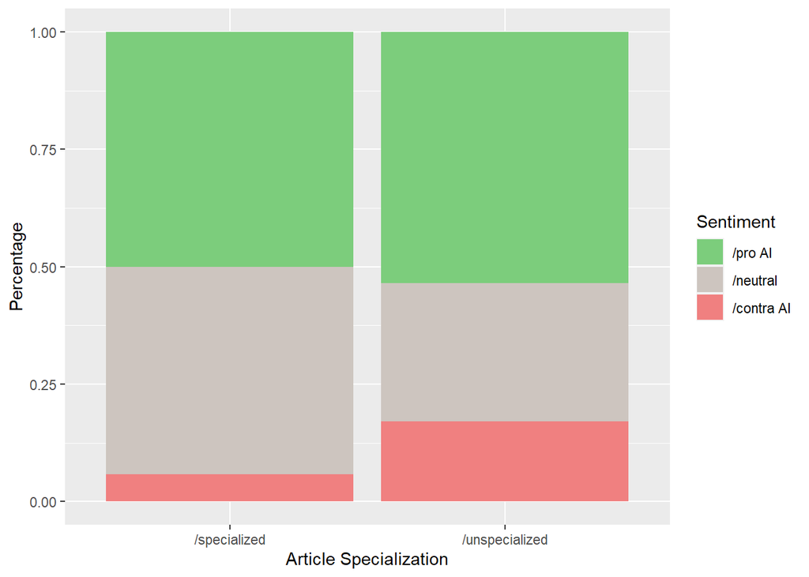

```r
ggplot(specialization_sentiment[c(1:3,8:10),], aes(fill=factor(Sentiment,levels=c("/pro AI","/neutral","/contra AI")), y=Count, x=Article_Specialization)) +
    geom_bar(position="fill", stat="identity") +
    labs(y = "Percentage", x = "Article Specialization",
         fill = "Sentiment") +
    scale_fill_manual(values=c("palegreen3","seashell3","lightcoral"))
```

In articles published on unspecialized platforms, more sentiments against AI and less neutral attitudes can be made out compared to articles written for specialized platforms.

## author expertise and percentage of sentiment

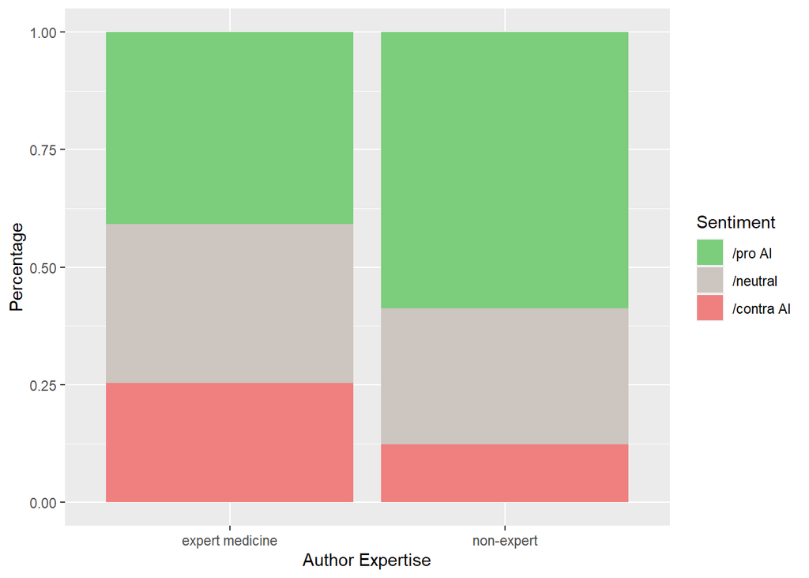

```r
ggplot(expert_sentiment, aes(fill=factor(Sentiment,levels=c("/pro AI","/neutral","/contra AI")), y=Count, x=Author)) +
    geom_bar(position="fill", stat="identity") +
    labs(y = "Percentage", x = "Author Expertise",
         fill = "Sentiment") +
    scale_fill_manual(values=c("palegreen3","seashell3","lightcoral"))
```

Medical experts on average are more negative and less positive towards AI compared to non-expert authors. Neutral attitudes are comparable between both author groups.

## year and percentage of sentiment

```r
# combine year and sentiment data
year_sentiment <- rbind(year_data, sentiment_data)
year_sentiment
```

|  | Tags | Total | 1 | 2 | 3 | 4 | 5 | 6 | 7 | 8 | 9 | 10 | 11 | 12 | 13 | 14 | 15 | 16 | 17 | 18 | 19 | 20 | 21 | 22 | 23 | 24 |
| --- | --- | --- | --- | --- | --- | --- | --- | --- | --- | --- | --- | --- | --- | --- | --- | --- | --- | --- | --- | --- | --- | --- | --- | --- | --- | --- |
| 1 | /2017 | 3 | NA | NA | NA | NA | NA | NA | NA | NA | NA | NA | NA | NA | NA | NA | NA | NA | 1 | 1 | NA | NA | NA | NA | 1 | NA |
| 2 | /2018 | 4 | NA | NA | NA | NA | NA | NA | NA | NA | NA | 1 | NA | 1 | NA | NA | NA | 1 | NA | NA | NA | 1 | NA | NA | NA | NA |
| 3 | /2019 | 8 | NA | 1 | NA | NA | NA | NA | NA | 1 | 1 | NA | NA | NA | 1 | NA | 1 | NA | NA | NA | NA | NA | 1 | 1 | NA | 1 |
| 4 | /2020 | 9 | 1 | NA | 1 | 1 | 1 | 1 | 1 | NA | NA | NA | 1 | NA | NA | 1 | NA | NA | NA | NA | 1 | NA | NA | NA | NA | NA |
| 34 | /pro AI | 126 | NA | 7 | 6 | NA | 4 | 11 | 4 | 9 | 1 | 3 | 10 | 7 | 2 | 3 | 7 | 2 | 4 | 4 | 7 | 11 | 4 | 14 | 2 | 4 |
| 30 | /neutral | 78 | 1 | 7 | 1 | 1 | 2 | NA | 6 | 3 | 1 | 4 | 6 | 3 | 4 | 5 | NA | NA | NA | NA | 4 | 13 | 2 | 10 | 1 | 4 |
| 26 | /contra AI | 35 | 3 | 2 | NA | NA | 2 | NA | 1 | 1 | 1 | 3 | 1 | 1 | NA | NA | 1 | NA | NA | NA | 1 | 3 | NA | 3 | NA | 12 |

```r
# summarize articles and counts
year_sentiment <- year_sentiment %>%
  pivot_longer(3:26, names_to = "article", values_to = "count") %>%
  drop_na()
year_sentiment
```

| Tags | Total | article | count |
| --- | --- | --- | --- |
| /2017 | 3 | 17 | 1 |
| /2017 | 3 | 18 | 1 |
| /2017 | 3 | 23 | 1 |
| /2018 | 4 | 10 | 1 |
| /2018 | 4 | 12 | 1 |
| /2018 | 4 | 16 | 1 |
| /2018 | 4 | 20 | 1 |
| /2019 | 8 | 2 | 1 |
| /2019 | 8 | 8 | 1 |
| /2019 | 8 | 9 | 1 |

[output cut: 69 more lines]

```r
sentim <- year_sentiment[25:79,]
year <- year_sentiment[1:24,]

# merge data based on the articles
year_sentiment <- merge.data.frame(sentim[-2],year[-2],by="article") %>%
                            select(c(2,3,4)) %>%
                            group_by(Tags.x, Tags.y) %>%
                            summarise_each(list(sum = sum)) %>%
                            rename("Sentiment" = 1, "Year" = 2, "Count" = 3)
year_sentiment
```

| Sentiment | Year | Count |
| --- | --- | --- |
| /contra AI | /2018 | 7 |
| /contra AI | /2019 | 20 |
| /contra AI | /2020 | 8 |
| /neutral | /2017 | 1 |
| /neutral | /2018 | 20 |
| /neutral | /2019 | 31 |
| /neutral | /2020 | 26 |
| /pro AI | /2017 | 10 |
| /pro AI | /2018 | 23 |
| /pro AI | /2019 | 48 |

[output cut: 1 more lines]

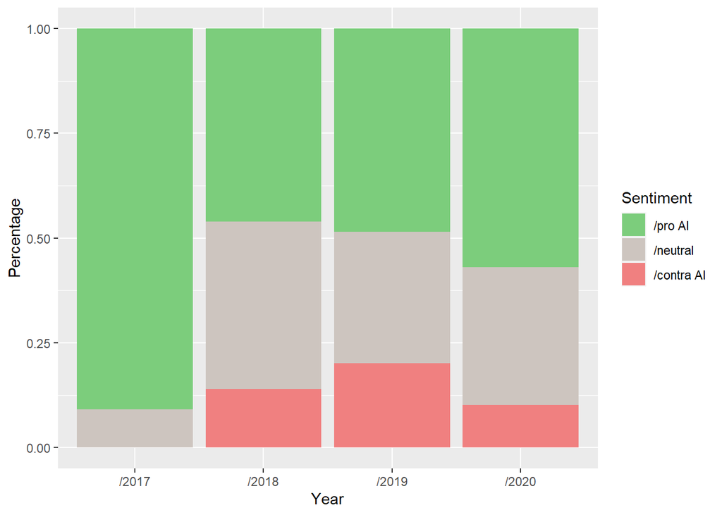

```r
ggplot(year_sentiment, aes(fill=factor(Sentiment,levels=c("/pro AI","/neutral","/contra AI")), y=Count, x=Year)) +
    geom_bar(position="fill", stat="identity") +
    labs(y = "Percentage", x = "Year",
         fill = "Sentiment") +
    scale_fill_manual(values=c("palegreen3","seashell3","lightcoral"))
```

## personal impression and percentage of sentiment

```r
# combine personal impression and sentiment data
impression_sentiment <- rbind(personal_impression_data, sentiment_data)
impression_sentiment
```

|  | Tags | Total | 1 | 2 | 3 | 4 | 5 | 6 | 7 | 8 | 9 | 10 | 11 | 12 | 13 | 14 | 15 | 16 | 17 | 18 | 19 | 20 | 21 | 22 | 23 | 24 |
| --- | --- | --- | --- | --- | --- | --- | --- | --- | --- | --- | --- | --- | --- | --- | --- | --- | --- | --- | --- | --- | --- | --- | --- | --- | --- | --- |
| 33 | /positive | 13 | NA | 1 | NA | NA | NA | 1 | NA | 1 | NA | NA | 1 | 1 | 1 | 1 | 1 | 1 | 1 | NA | 1 | 1 | NA | NA | 1 | NA |
| 29 | /neither positive nor negative | 8 | NA | NA | 1 | 1 | 1 | NA | 1 | NA | 1 | NA | NA | NA | NA | NA | NA | NA | NA | 1 | NA | NA | 1 | 1 | NA | NA |
| 28 | /negative | 3 | 1 | NA | NA | NA | NA | NA | NA | NA | NA | 1 | NA | NA | NA | NA | NA | NA | NA | NA | NA | NA | NA | NA | NA | 1 |
| 34 | /pro AI | 126 | NA | 7 | 6 | NA | 4 | 11 | 4 | 9 | 1 | 3 | 10 | 7 | 2 | 3 | 7 | 2 | 4 | 4 | 7 | 11 | 4 | 14 | 2 | 4 |
| 30 | /neutral | 78 | 1 | 7 | 1 | 1 | 2 | NA | 6 | 3 | 1 | 4 | 6 | 3 | 4 | 5 | NA | NA | NA | NA | 4 | 13 | 2 | 10 | 1 | 4 |
| 26 | /contra AI | 35 | 3 | 2 | NA | NA | 2 | NA | 1 | 1 | 1 | 3 | 1 | 1 | NA | NA | 1 | NA | NA | NA | 1 | 3 | NA | 3 | NA | 12 |

```r
impression_sentiment <- impression_sentiment %>%
  pivot_longer(3:26, names_to = "article", values_to = "count") %>%
  drop_na()
impression_sentiment
```

| Tags | Total | article | count |
| --- | --- | --- | --- |
| /positive | 13 | 2 | 1 |
| /positive | 13 | 6 | 1 |
| /positive | 13 | 8 | 1 |
| /positive | 13 | 11 | 1 |
| /positive | 13 | 12 | 1 |
| /positive | 13 | 13 | 1 |
| /positive | 13 | 14 | 1 |
| /positive | 13 | 15 | 1 |
| /positive | 13 | 16 | 1 |
| /positive | 13 | 17 | 1 |

[output cut: 69 more lines]

```r
impr <- impression_sentiment[1:24,]
sentim <- impression_sentiment[25:79,]

impression_sentiment <- merge.data.frame(impr[-2],sentim[-2],by="article") %>%
                            select(c(2,4,5)) %>%
                            group_by(Tags.x, Tags.y) %>%
                            summarise_each(list(sum = sum)) %>%
                            rename("Personal_Impression" = 1, "Sentiment" = 2, "Count" = 3)
impression_sentiment
```

| Personal_Impression | Sentiment | Count |
| --- | --- | --- |
| /negative | /contra AI | 18 |
| /negative | /neutral | 9 |
| /negative | /pro AI | 7 |
| /neither positive nor negative | /contra AI | 7 |
| /neither positive nor negative | /neutral | 23 |
| /neither positive nor negative | /pro AI | 37 |
| /positive | /contra AI | 10 |
| /positive | /neutral | 46 |
| /positive | /pro AI | 82 |

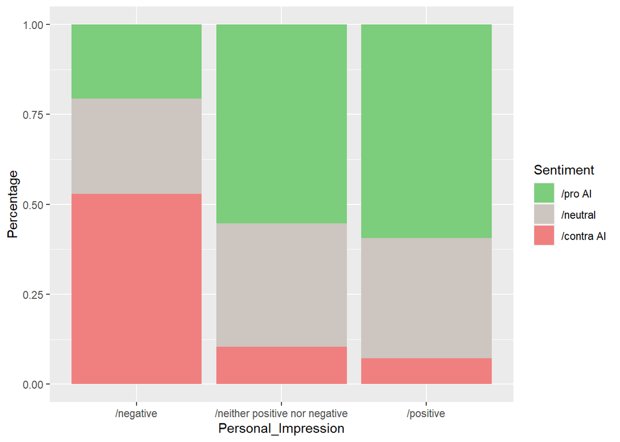

```r
ggplot(impression_sentiment, aes(fill=factor(Sentiment, levels=c("/pro AI","/neutral","/contra AI")), y=Count, x=Personal_Impression)) +
    geom_bar(position="fill", stat="identity") +
    labs(y = "Percentage",
         fill = "Sentiment") +
    theme(plot.title = element_text(hjust = 0.5, size = 14)) +
    scale_fill_manual(values=c("palegreen3","seashell3","lightcoral"))
```

Out of curiosity, we tagged our personal impressions once per article without clear guidelines as we wanted to capture our subjective impression of their general attitude toward the usage of AI in medicine. Especially interesting here is that the articles that seem rather neutral to us address several arguments in favor of AI, very much equally often as those that seem positive to us. The articles we perceive as negative and positive instead discuss more arguments against or in favor of AI, respectively, and thus our impressions are somewhat in line with the sentiments.

# personal impression

## personal impression total

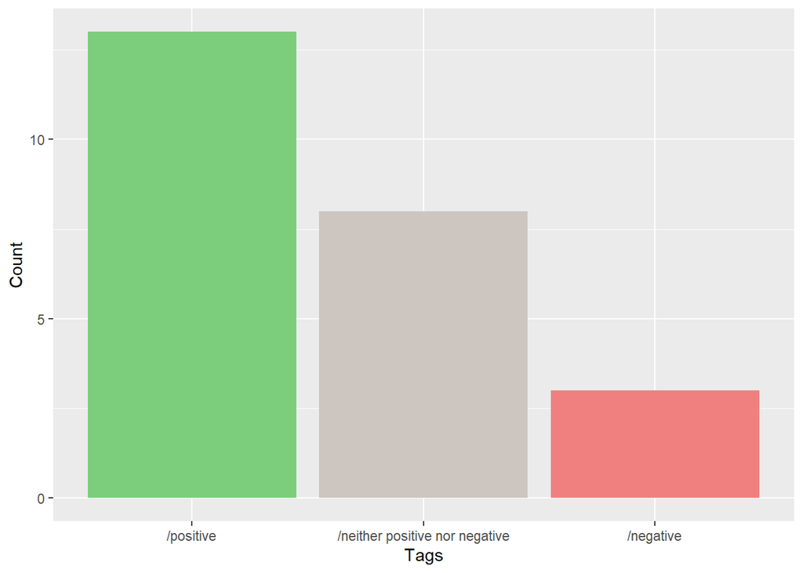

```r
ggplot(personal_impression_data, aes(fill=factor(Tags,levels=c("/positive","/neither positive nor negative","/negative")), y=Total, x=factor(Tags,levels=c("/positive","/neither positive nor negative","/negative")))) +
    geom_bar(position="dodge", stat="identity") +
    labs(x = "Tags", y = "Count") +
    theme(legend.position = "none") +
    scale_fill_manual(values=c("palegreen3","seashell3","lightcoral"))
```

Rather unsurprisingly, we perceive the majority of the sources to be overall positive about the application of AI in medicine, while only a few of them seem to be generally negative about that.

## article specialization and percentage of personal impression

```r
# combine article specialization and personal impression data
specialization_impression <- rbind(specialization_data, personal_impression_data)
specialization_impression
```

|  | Tags | Total | 1 | 2 | 3 | 4 | 5 | 6 | 7 | 8 | 9 | 10 | 11 | 12 | 13 | 14 | 15 | 16 | 17 | 18 | 19 | 20 | 21 | 22 | 23 | 24 |
| --- | --- | --- | --- | --- | --- | --- | --- | --- | --- | --- | --- | --- | --- | --- | --- | --- | --- | --- | --- | --- | --- | --- | --- | --- | --- | --- |
| 36 | /specialized | 7 | NA | NA | NA | 1 | NA | NA | NA | NA | NA | NA | NA | NA | 1 | 1 | NA | 1 | 1 | 1 | NA | 1 | NA | NA | NA | NA |
| 37 | /specialized/expert (author)/medicine | 1 | NA | NA | NA | NA | NA | NA | NA | NA | NA | NA | NA | NA | NA | NA | NA | NA | NA | NA | NA | 1 | NA | NA | NA | NA |
| 38 | /specialized/non-expert (author) | 1 | NA | NA | NA | NA | NA | NA | NA | NA | NA | NA | NA | NA | NA | NA | NA | NA | NA | 1 | NA | NA | NA | NA | NA | NA |
| 41 | /unspecialized | 17 | 1 | 1 | 1 | NA | 1 | 1 | 1 | 1 | 1 | 1 | 1 | 1 | NA | NA | 1 | NA | NA | NA | 1 | NA | 1 | 1 | 1 | 1 |
| 42 | /unspecialized/expert (author)/medicine | 3 | NA | 1 | NA | NA | NA | NA | NA | NA | NA | NA | NA | NA | NA | NA | 1 | NA | NA | NA | NA | NA | NA | NA | NA | 1 |
| 43 | /unspecialized/non-expert (author) | 11 | 1 | NA | 1 | NA | 1 | 1 | 1 | 1 | NA | 1 | NA | 1 | NA | NA | NA | NA | NA | NA | 1 | NA | NA | 1 | 1 | NA |
| 33 | /positive | 13 | NA | 1 | NA | NA | NA | 1 | NA | 1 | NA | NA | 1 | 1 | 1 | 1 | 1 | 1 | 1 | NA | 1 | 1 | NA | NA | 1 | NA |
| 29 | /neither positive nor negative | 8 | NA | NA | 1 | 1 | 1 | NA | 1 | NA | 1 | NA | NA | NA | NA | NA | NA | NA | NA | 1 | NA | NA | 1 | 1 | NA | NA |
| 28 | /negative | 3 | 1 | NA | NA | NA | NA | NA | NA | NA | NA | 1 | NA | NA | NA | NA | NA | NA | NA | NA | NA | NA | NA | NA | NA | 1 |

```r
# summarize articles and counts
specialization_impression <- specialization_impression %>%
  pivot_longer(3:26, names_to = "article", values_to = "count") %>%
  drop_na()
specialization_impression
```

| Tags | Total | article | count |
| --- | --- | --- | --- |
| /specialized | 7 | 4 | 1 |
| /specialized | 7 | 13 | 1 |
| /specialized | 7 | 14 | 1 |
| /specialized | 7 | 16 | 1 |
| /specialized | 7 | 17 | 1 |
| /specialized | 7 | 18 | 1 |
| /specialized | 7 | 20 | 1 |
| /specialized/expert (author)/medicine | 1 | 20 | 1 |
| /specialized/non-expert (author) | 1 | 18 | 1 |
| /unspecialized | 17 | 1 | 1 |

[output cut: 54 more lines]

```r
spec <- specialization_impression[c(1:40),]
impr <- specialization_impression[41:64,]

# merge data based on the articles
specialization_impression <- merge.data.frame(spec[-2],impr[-2],by="article") %>%
                            select(c(2,4,5)) %>%
                            group_by(Tags.x, Tags.y) %>%
                            summarise_each(list(sum = sum)) %>%
                            rename("Article_Specialization" = 1, "Personal_Impression" = 2, "Count" = 3)
specialization_impression
```

| Article_Specialization | Personal_Impression | Count |
| --- | --- | --- |
| /specialized | /neither positive nor negative | 2 |
| /specialized | /positive | 5 |
| /specialized/expert (author)/medicine | /positive | 1 |
| /specialized/non-expert (author) | /neither positive nor negative | 1 |
| /unspecialized | /negative | 3 |
| /unspecialized | /neither positive nor negative | 6 |
| /unspecialized | /positive | 8 |
| /unspecialized/expert (author)/medicine | /negative | 1 |
| /unspecialized/expert (author)/medicine | /positive | 2 |
| /unspecialized/non-expert (author) | /negative | 2 |

[output cut: 2 more lines]

```r
# extract author expertise data
expert_impression <- specialization_impression[c(3,4,8:12),]
expert_impression$Article_Specialization <- c("expert medicine","non-expert",rep("expert medicine",2),rep("non-expert",3))
expert_impression <- expert_impression %>%
                    group_by(Article_Specialization, Personal_Impression) %>%
                    summarise_each(list(sum = sum)) %>%
                    rename("Author" = 1, "Count" = 3)
expert_impression
```

| Author | Personal_Impression | Count |
| --- | --- | --- |
| expert medicine | /negative | 1 |
| expert medicine | /positive | 3 |
| non-expert | /negative | 2 |
| non-expert | /neither positive nor negative | 5 |
| non-expert | /positive | 5 |

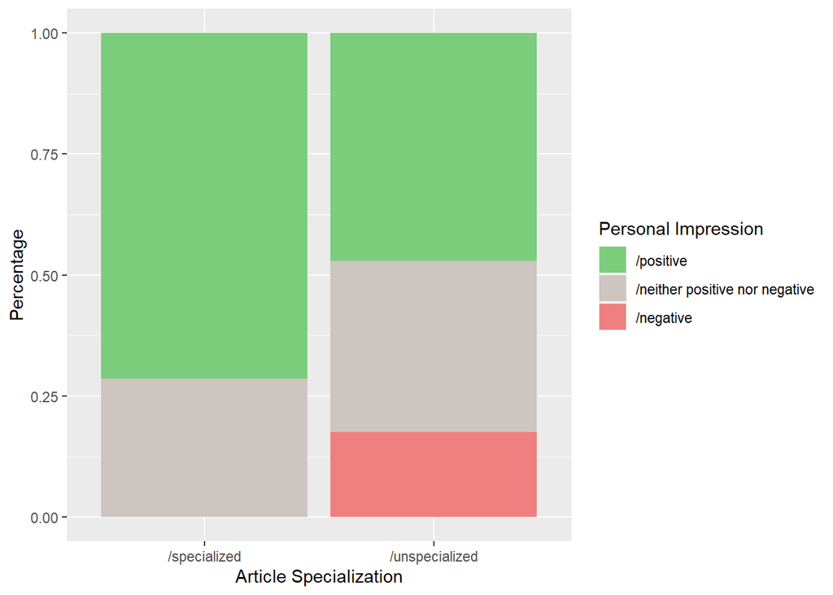

```r
ggplot(specialization_impression[c(1,2,5:7),], aes(fill=factor(Personal_Impression,levels=c("/positive","/neither positive nor negative","/negative")), y=Count, x=Article_Specialization)) +
    geom_bar(position="fill", stat="identity") +
    labs(y = "Percentage",
         x = "Article Specialization",
         fill = "Personal Impression") +
    scale_fill_manual(values=c("palegreen3","seashell3","lightcoral"))
```

None of the specialized articles seem negative about the application of AI in medicine to us and instead the majority seem positive about that. There are some unspecialized articles that seem negative about it, while we perceive overall neutral or positive attitudes nearly equally often among them.

## author expertise and percentage of personal impression

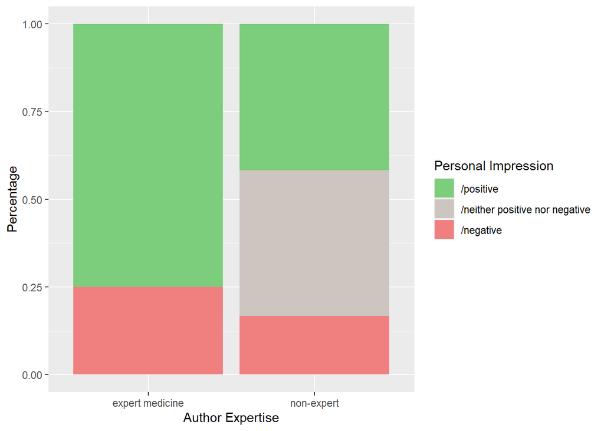

```r
ggplot(expert_impression, aes(fill=factor(Personal_Impression,levels=c("/positive","/neither positive nor negative","/negative")), y=Count, x=Author)) +
    geom_bar(position="fill", stat="identity") +
    labs(y = "Percentage",
         x = "Author Expertise",
         fill = "Personal Impression") +
    scale_fill_manual(values=c("palegreen3","seashell3","lightcoral"))
```

All articles written by medical experts seem decidedly positive or negative about the application of AI, with a clear majority of positive articles. The majority of the articles written by non-experts seem rather neutral or positive, while we perceive less of them as negative, also in comparison to the expert-written articles.

## year and percentage of personal impression

```r
# combine year and personal impression data
year_impression <- rbind(year_data, personal_impression_data)
year_impression
```

|  | Tags | Total | 1 | 2 | 3 | 4 | 5 | 6 | 7 | 8 | 9 | 10 | 11 | 12 | 13 | 14 | 15 | 16 | 17 | 18 | 19 | 20 | 21 | 22 | 23 | 24 |
| --- | --- | --- | --- | --- | --- | --- | --- | --- | --- | --- | --- | --- | --- | --- | --- | --- | --- | --- | --- | --- | --- | --- | --- | --- | --- | --- |
| 1 | /2017 | 3 | NA | NA | NA | NA | NA | NA | NA | NA | NA | NA | NA | NA | NA | NA | NA | NA | 1 | 1 | NA | NA | NA | NA | 1 | NA |
| 2 | /2018 | 4 | NA | NA | NA | NA | NA | NA | NA | NA | NA | 1 | NA | 1 | NA | NA | NA | 1 | NA | NA | NA | 1 | NA | NA | NA | NA |
| 3 | /2019 | 8 | NA | 1 | NA | NA | NA | NA | NA | 1 | 1 | NA | NA | NA | 1 | NA | 1 | NA | NA | NA | NA | NA | 1 | 1 | NA | 1 |
| 4 | /2020 | 9 | 1 | NA | 1 | 1 | 1 | 1 | 1 | NA | NA | NA | 1 | NA | NA | 1 | NA | NA | NA | NA | 1 | NA | NA | NA | NA | NA |
| 33 | /positive | 13 | NA | 1 | NA | NA | NA | 1 | NA | 1 | NA | NA | 1 | 1 | 1 | 1 | 1 | 1 | 1 | NA | 1 | 1 | NA | NA | 1 | NA |
| 29 | /neither positive nor negative | 8 | NA | NA | 1 | 1 | 1 | NA | 1 | NA | 1 | NA | NA | NA | NA | NA | NA | NA | NA | 1 | NA | NA | 1 | 1 | NA | NA |
| 28 | /negative | 3 | 1 | NA | NA | NA | NA | NA | NA | NA | NA | 1 | NA | NA | NA | NA | NA | NA | NA | NA | NA | NA | NA | NA | NA | 1 |

```r
# summarize articles and counts
year_impression <- year_impression %>%
  pivot_longer(3:26, names_to = "article", values_to = "count") %>%
  drop_na()
year_impression
```

| Tags | Total | article | count |
| --- | --- | --- | --- |
| /2017 | 3 | 17 | 1 |
| /2017 | 3 | 18 | 1 |
| /2017 | 3 | 23 | 1 |
| /2018 | 4 | 10 | 1 |
| /2018 | 4 | 12 | 1 |
| /2018 | 4 | 16 | 1 |
| /2018 | 4 | 20 | 1 |
| /2019 | 8 | 2 | 1 |
| /2019 | 8 | 8 | 1 |
| /2019 | 8 | 9 | 1 |

[output cut: 38 more lines]

```r
impr <- year_impression[25:48,]
year <- year_impression[1:24,]

# merge data based on the articles
year_impression <- merge.data.frame(impr[-2],year[-2],by="article") %>%
                            select(c(2,3,4)) %>%
                            group_by(Tags.x, Tags.y) %>%
                            summarise_each(list(sum = sum)) %>%
                            rename("Personal_Impression" = 1, "Year" = 2, "Count" = 3)
year_impression
```

| Personal_Impression | Year | Count |
| --- | --- | --- |
| /negative | /2018 | 1 |
| /negative | /2019 | 1 |
| /negative | /2020 | 1 |
| /neither positive nor negative | /2017 | 1 |
| /neither positive nor negative | /2019 | 3 |
| /neither positive nor negative | /2020 | 4 |
| /positive | /2017 | 2 |
| /positive | /2018 | 3 |
| /positive | /2019 | 4 |
| /positive | /2020 | 4 |

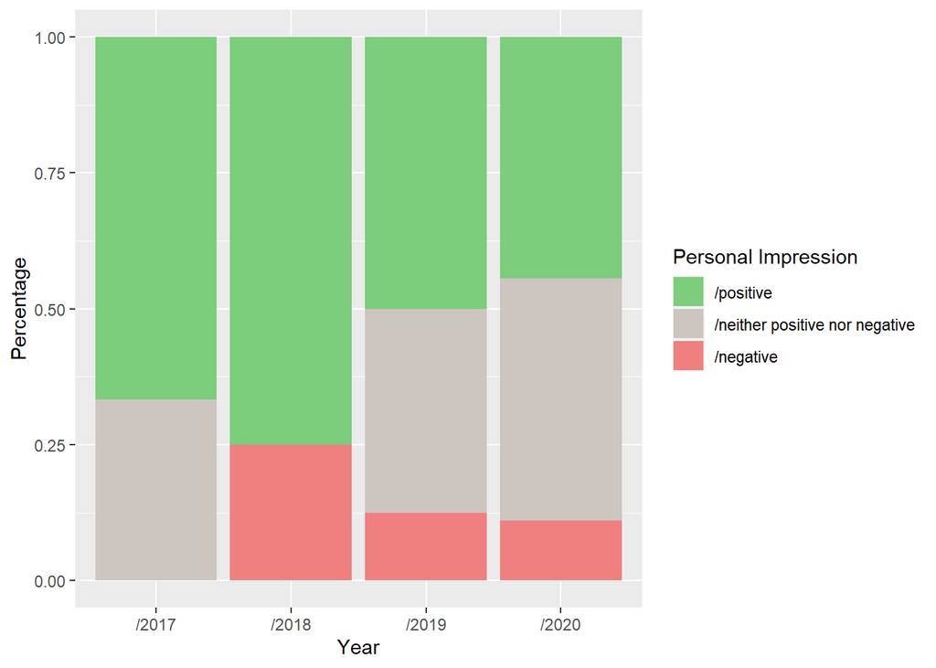

```r
ggplot(year_impression, aes(fill=factor(Personal_Impression,levels=c("/positive","/neither positive nor negative","/negative")), y=Count, x=Year)) +
    geom_bar(position="fill", stat="identity") +
    labs(y = "Percentage",
         fill = "Personal Impression") +
    scale_fill_manual(values=c("palegreen3","seashell3","lightcoral"))
```

The articles written in 2017 seem more positive than neutral to us, while none of them seem negative. With those written in 2018 or later, we can see a linear development again - with every year, the number of articles we perceive as decidedly positive and negative towards the applications of AI decreases, while the ones we perceive as rather neutral increases.

# SWOT

## SWOT total

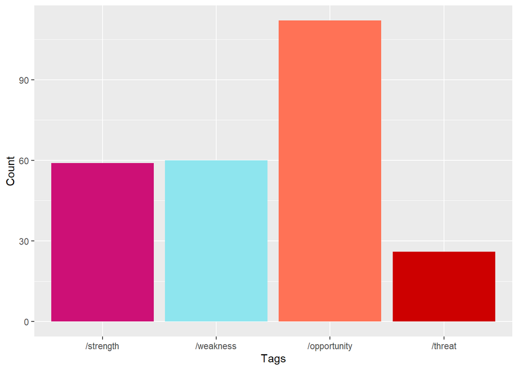

```r
ggplot(SWOT_data, aes(fill=factor(Tags, levels=c("/strength","/weakness","/opportunity","/threat")), y=Total, x=factor(Tags, levels=c("/strength","/weakness","/opportunity","/threat")))) +
    geom_bar(position="dodge", stat="identity") +
    labs(y = "Count",
         x = "Tags") +
    theme(legend.position = "none") +
    scale_fill_manual(values=c("deeppink3","cadetblue2","coral1","red3"))
```

Opportunities are mentioned clearly the most often, while strengths and weaknesses are discussed nearly equally often. Threats are brought up about half as often as those.

## article specialization and percentage of SWOT

```r
# combine article specialization and SWOT data
specialization_SWOT <- rbind(specialization_data, SWOT_data)
specialization_SWOT
```

|  | Tags | Total | 1 | 2 | 3 | 4 | 5 | 6 | 7 | 8 | 9 | 10 | 11 | 12 | 13 | 14 | 15 | 16 | 17 | 18 | 19 | 20 | 21 | 22 | 23 | 24 |
| --- | --- | --- | --- | --- | --- | --- | --- | --- | --- | --- | --- | --- | --- | --- | --- | --- | --- | --- | --- | --- | --- | --- | --- | --- | --- | --- |
| 36 | /specialized | 7 | NA | NA | NA | 1 | NA | NA | NA | NA | NA | NA | NA | NA | 1 | 1 | NA | 1 | 1 | 1 | NA | 1 | NA | NA | NA | NA |
| 37 | /specialized/expert (author)/medicine | 1 | NA | NA | NA | NA | NA | NA | NA | NA | NA | NA | NA | NA | NA | NA | NA | NA | NA | NA | NA | 1 | NA | NA | NA | NA |
| 38 | /specialized/non-expert (author) | 1 | NA | NA | NA | NA | NA | NA | NA | NA | NA | NA | NA | NA | NA | NA | NA | NA | NA | 1 | NA | NA | NA | NA | NA | NA |
| 41 | /unspecialized | 17 | 1 | 1 | 1 | NA | 1 | 1 | 1 | 1 | 1 | 1 | 1 | 1 | NA | NA | 1 | NA | NA | NA | 1 | NA | 1 | 1 | 1 | 1 |
| 42 | /unspecialized/expert (author)/medicine | 3 | NA | 1 | NA | NA | NA | NA | NA | NA | NA | NA | NA | NA | NA | NA | 1 | NA | NA | NA | NA | NA | NA | NA | NA | 1 |
| 43 | /unspecialized/non-expert (author) | 11 | 1 | NA | 1 | NA | 1 | 1 | 1 | 1 | NA | 1 | NA | 1 | NA | NA | NA | NA | NA | NA | 1 | NA | NA | 1 | 1 | NA |
| 39 | /strength | 59 | NA | 1 | 2 | NA | 2 | 4 | 3 | 3 | 2 | 1 | 4 | 8 | NA | 1 | 2 | 3 | 3 | NA | 2 | 1 | 2 | 10 | 3 | 2 |
| 44 | /weakness | 60 | 2 | 5 | 1 | 1 | 3 | NA | 6 | 2 | 1 | 3 | 4 | NA | NA | 2 | 5 | NA | NA | NA | 5 | 2 | 2 | 4 | 2 | 10 |
| 32 | /opportunity | 112 | NA | 2 | 6 | 1 | 7 | 2 | 5 | 6 | 2 | 3 | 6 | 7 | 2 | 6 | 8 | NA | 3 | 2 | 9 | 10 | 9 | 14 | 1 | 1 |
| 40 | /threat | 26 | 1 | 1 | 3 | NA | 5 | NA | NA | 3 | NA | 1 | 1 | NA | NA | 2 | 2 | NA | NA | NA | NA | 2 | NA | 2 | 1 | 2 |

```r
# summarize articles and counts
specialization_SWOT <- specialization_SWOT %>%
  pivot_longer(3:26, names_to = "article", values_to = "count") %>%
  drop_na()
specialization_SWOT
```

| Tags | Total | article | count |
| --- | --- | --- | --- |
| /specialized | 7 | 4 | 1 |
| /specialized | 7 | 13 | 1 |
| /specialized | 7 | 14 | 1 |
| /specialized | 7 | 16 | 1 |
| /specialized | 7 | 17 | 1 |
| /specialized | 7 | 18 | 1 |
| /specialized | 7 | 20 | 1 |
| /specialized/expert (author)/medicine | 1 | 20 | 1 |
| /specialized/non-expert (author) | 1 | 18 | 1 |
| /unspecialized | 17 | 1 | 1 |

[output cut: 103 more lines]

```r
spec <- specialization_SWOT[c(1:40),]
swot <- specialization_SWOT[41:113,]

# merge data based on the articles
specialization_SWOT <- merge.data.frame(spec[-2],swot[-2],by="article") %>%
                            select(c(2,4,5)) %>%
                            group_by(Tags.x, Tags.y) %>%
                            summarise_each(list(sum = sum)) %>%
                            rename("Article_Specialization" = 1, "SWOT" = 2, "Count" = 3)
specialization_SWOT
```

| Article_Specialization | SWOT | Count |
| --- | --- | --- |
| /specialized | /opportunity | 24 |
| /specialized | /strength | 8 |
| /specialized | /threat | 4 |
| /specialized | /weakness | 5 |
| /specialized/expert (author)/medicine | /opportunity | 10 |
| /specialized/expert (author)/medicine | /strength | 1 |
| /specialized/expert (author)/medicine | /threat | 2 |
| /specialized/expert (author)/medicine | /weakness | 2 |
| /specialized/non-expert (author) | /opportunity | 2 |
| /unspecialized | /opportunity | 88 |

[output cut: 11 more lines]

```r
# extract author expertise data
expert_SWOT <- specialization_SWOT[c(5:9,14:21),]
expert_SWOT$Article_Specialization <- c(rep("expert medicine",4),"non-expert",rep("expert medicine",4),rep("non-expert",4))
expert_SWOT <- expert_SWOT %>%
                    group_by(Article_Specialization, SWOT) %>%
                    summarise_each(list(sum = sum)) %>%
                    rename("Author" = 1, "Count" = 3)
expert_SWOT
```

| Author | SWOT | Count |
| --- | --- | --- |
| expert medicine | /opportunity | 21 |
| expert medicine | /strength | 6 |
| expert medicine | /threat | 7 |
| expert medicine | /weakness | 22 |
| non-expert | /opportunity | 62 |
| non-expert | /strength | 38 |
| non-expert | /threat | 16 |
| non-expert | /weakness | 28 |

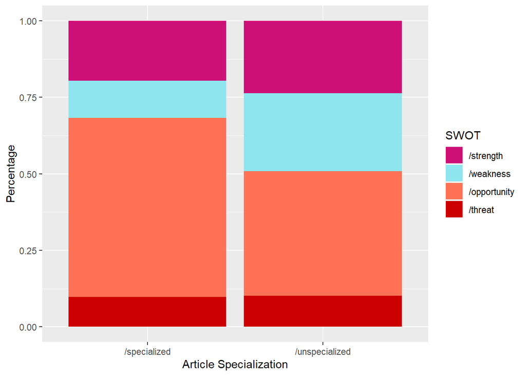

```r
ggplot(specialization_SWOT[c(1:4,10:13),], aes(fill=factor(SWOT, levels=c("/strength","/weakness","/opportunity","/threat")), y=Count, x=Article_Specialization)) +
    geom_bar(position="fill", stat="identity") +
    labs(y = "Percentage",
         x = "Article Specialization",
         fill = "SWOT") +
    scale_fill_manual(values=c("deeppink3","cadetblue2","coral1","red3"))
```

While the amount of mentioned strengths and threats are comparable for both kind of platforms, the articles written for specialized platforms discuss more opportunities. In turn, the articles written for unspecialized platforms bring up more weaknesses.

## author expertise and percentage of SWOT

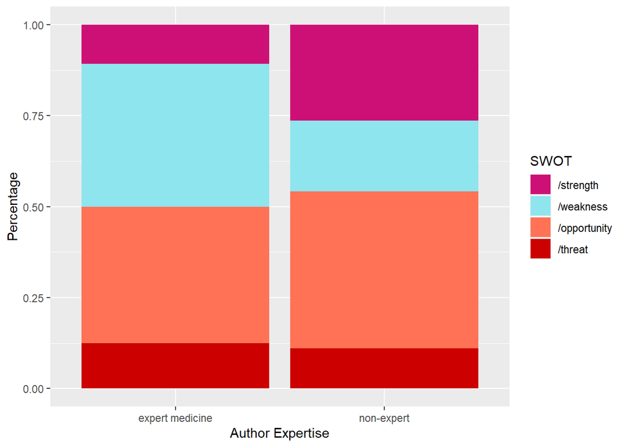

```r
ggplot(expert_SWOT, aes(fill=factor(SWOT, levels=c("/strength","/weakness","/opportunity","/threat")), y=Count, x=Author)) +
    geom_bar(position="fill", stat="identity") +
    labs(y = "Percentage",
         x = "Author Expertise",
         fill = "SWOT") +
    scale_fill_manual(values=c("deeppink3","cadetblue2","coral1","red3"))
```

The number of discussed threats is again comparable for both kind of authors, while this time also the amount of mentioned opportunities is nearly equal. Medical experts address far more weaknesses than strengths, while non-experts mention noticeable more strengths than weaknesses.

## year and percentage of SWOT

```r
# combine year and SWOT data
year_SWOT <- rbind(year_data, SWOT_data)
year_SWOT
```

|  | Tags | Total | 1 | 2 | 3 | 4 | 5 | 6 | 7 | 8 | 9 | 10 | 11 | 12 | 13 | 14 | 15 | 16 | 17 | 18 | 19 | 20 | 21 | 22 | 23 | 24 |
| --- | --- | --- | --- | --- | --- | --- | --- | --- | --- | --- | --- | --- | --- | --- | --- | --- | --- | --- | --- | --- | --- | --- | --- | --- | --- | --- |
| 1 | /2017 | 3 | NA | NA | NA | NA | NA | NA | NA | NA | NA | NA | NA | NA | NA | NA | NA | NA | 1 | 1 | NA | NA | NA | NA | 1 | NA |
| 2 | /2018 | 4 | NA | NA | NA | NA | NA | NA | NA | NA | NA | 1 | NA | 1 | NA | NA | NA | 1 | NA | NA | NA | 1 | NA | NA | NA | NA |
| 3 | /2019 | 8 | NA | 1 | NA | NA | NA | NA | NA | 1 | 1 | NA | NA | NA | 1 | NA | 1 | NA | NA | NA | NA | NA | 1 | 1 | NA | 1 |
| 4 | /2020 | 9 | 1 | NA | 1 | 1 | 1 | 1 | 1 | NA | NA | NA | 1 | NA | NA | 1 | NA | NA | NA | NA | 1 | NA | NA | NA | NA | NA |
| 39 | /strength | 59 | NA | 1 | 2 | NA | 2 | 4 | 3 | 3 | 2 | 1 | 4 | 8 | NA | 1 | 2 | 3 | 3 | NA | 2 | 1 | 2 | 10 | 3 | 2 |
| 44 | /weakness | 60 | 2 | 5 | 1 | 1 | 3 | NA | 6 | 2 | 1 | 3 | 4 | NA | NA | 2 | 5 | NA | NA | NA | 5 | 2 | 2 | 4 | 2 | 10 |
| 32 | /opportunity | 112 | NA | 2 | 6 | 1 | 7 | 2 | 5 | 6 | 2 | 3 | 6 | 7 | 2 | 6 | 8 | NA | 3 | 2 | 9 | 10 | 9 | 14 | 1 | 1 |
| 40 | /threat | 26 | 1 | 1 | 3 | NA | 5 | NA | NA | 3 | NA | 1 | 1 | NA | NA | 2 | 2 | NA | NA | NA | NA | 2 | NA | 2 | 1 | 2 |

```r
# summarize articles and counts
year_SWOT <- year_SWOT %>%
  pivot_longer(3:26, names_to = "article", values_to = "count") %>%
  drop_na()
year_SWOT
```

| Tags | Total | article | count |
| --- | --- | --- | --- |
| /2017 | 3 | 17 | 1 |
| /2017 | 3 | 18 | 1 |
| /2017 | 3 | 23 | 1 |
| /2018 | 4 | 10 | 1 |
| /2018 | 4 | 12 | 1 |
| /2018 | 4 | 16 | 1 |
| /2018 | 4 | 20 | 1 |
| /2019 | 8 | 2 | 1 |
| /2019 | 8 | 8 | 1 |
| /2019 | 8 | 9 | 1 |

[output cut: 87 more lines]

```r
swot <- year_SWOT[25:97,]
year <- year_SWOT[1:24,]

# merge data based on the articles
year_SWOT <- merge.data.frame(swot[-2],year[-2],by="article") %>%
                            select(c(2,3,4)) %>%
                            group_by(Tags.x, Tags.y) %>%
                            summarise_each(list(sum = sum)) %>%
                            rename("SWOT" = 1, "Year" = 2, "Count" = 3)
year_SWOT
```

| SWOT | Year | Count |
| --- | --- | --- |
| /opportunity | /2017 | 6 |
| /opportunity | /2018 | 20 |
| /opportunity | /2019 | 44 |
| /opportunity | /2020 | 42 |
| /strength | /2017 | 6 |
| /strength | /2018 | 13 |
| /strength | /2019 | 22 |
| /strength | /2020 | 18 |
| /threat | /2017 | 1 |
| /threat | /2018 | 3 |

[output cut: 6 more lines]

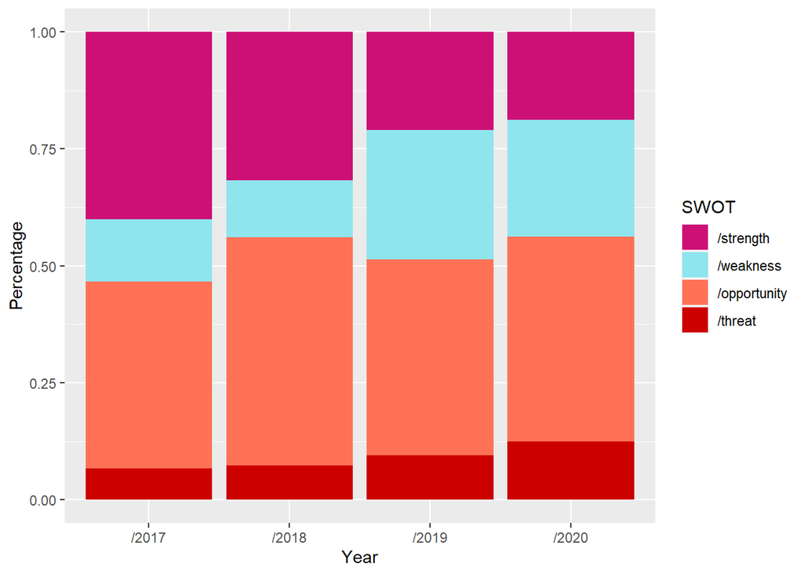

```r
ggplot(year_SWOT, aes(fill=factor(SWOT, levels=c("/strength","/weakness","/opportunity","/threat")), y=Count, x=Year)) +
    geom_bar(position="fill", stat="identity") +
    labs(y = "Percentage",
         fill = "SWOT") +
    scale_fill_manual(values=c("deeppink3","cadetblue2","coral1","red3"))
```

For the temporal development of the amount of discussed SWOTs, a rapid linear decrease can be made out for strengths, while a small increase is visible for threats. The amount of mentioned opportunities is rather consistent. While the number of mentioned weaknesses is nearly equal for articles written in 2017 and 2018, a rapid increase seems to happen for articles written later than that.

# synonyms

## synonyms total

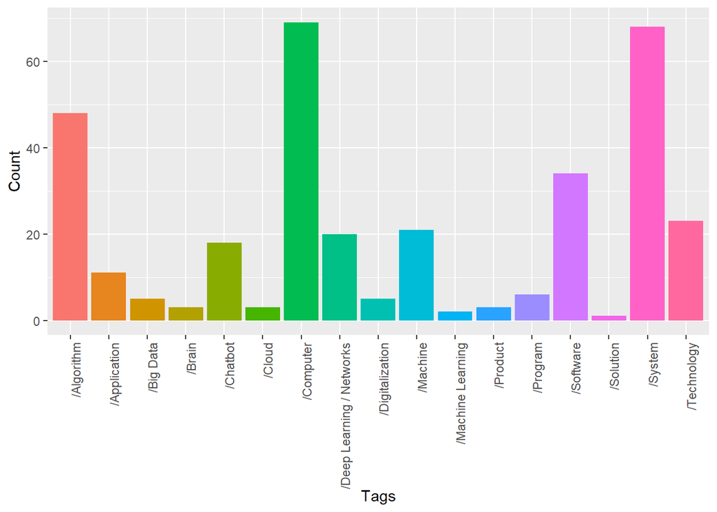

```r
ggplot(synonym_data, aes(fill=Tags, y=Total, x=Tags)) +
    geom_bar(position="dodge", stat="identity") +
    labs(y = "Count",
         x = "Tags") +
    theme(axis.text.x=element_text(angle=90,hjust=1),
          legend.position = "none")
```

## article specialization and percentage of synonyms

```r
# combine article specialization and synonym data
specialization_synonyms <- rbind(specialization_data, synonym_data)
specialization_synonyms
```

|  | Tags | Total | 1 | 2 | 3 | 4 | 5 | 6 | 7 | 8 | 9 | 10 | 11 | 12 | 13 | 14 | 15 | 16 | 17 | 18 | 19 | 20 | 21 | 22 | 23 | 24 |
| --- | --- | --- | --- | --- | --- | --- | --- | --- | --- | --- | --- | --- | --- | --- | --- | --- | --- | --- | --- | --- | --- | --- | --- | --- | --- | --- |
| 36 | /specialized | 7 | NA | NA | NA | 1 | NA | NA | NA | NA | NA | NA | NA | NA | 1 | 1 | NA | 1 | 1 | 1 | NA | 1 | NA | NA | NA | NA |
| 37 | /specialized/expert (author)/medicine | 1 | NA | NA | NA | NA | NA | NA | NA | NA | NA | NA | NA | NA | NA | NA | NA | NA | NA | NA | NA | 1 | NA | NA | NA | NA |
| 38 | /specialized/non-expert (author) | 1 | NA | NA | NA | NA | NA | NA | NA | NA | NA | NA | NA | NA | NA | NA | NA | NA | NA | 1 | NA | NA | NA | NA | NA | NA |
| 41 | /unspecialized | 17 | 1 | 1 | 1 | NA | 1 | 1 | 1 | 1 | 1 | 1 | 1 | 1 | NA | NA | 1 | NA | NA | NA | 1 | NA | 1 | 1 | 1 | 1 |
| 42 | /unspecialized/expert (author)/medicine | 3 | NA | 1 | NA | NA | NA | NA | NA | NA | NA | NA | NA | NA | NA | NA | 1 | NA | NA | NA | NA | NA | NA | NA | NA | 1 |
| 43 | /unspecialized/non-expert (author) | 11 | 1 | NA | 1 | NA | 1 | 1 | 1 | 1 | NA | 1 | NA | 1 | NA | NA | NA | NA | NA | NA | 1 | NA | NA | 1 | 1 | NA |
| 5 | /Algorithm | 48 | 9 | 2 | 1 | NA | 9 | NA | 6 | NA | NA | NA | NA | NA | NA | NA | 1 | NA | 4 | NA | NA | 1 | NA | 7 | NA | 8 |
| 6 | /Application | 11 | NA | NA | 1 | NA | NA | NA | NA | 2 | NA | NA | NA | NA | NA | 1 | NA | NA | NA | 1 | NA | 2 | NA | 4 | NA | NA |
| 7 | /Big Data | 5 | NA | NA | NA | NA | 2 | NA | NA | NA | NA | NA | NA | 1 | NA | NA | NA | NA | NA | NA | NA | 2 | NA | NA | NA | NA |
| 8 | /Brain | 3 | NA | NA | 3 | NA | NA | NA | NA | NA | NA | NA | NA | NA | NA | NA | NA | NA | NA | NA | NA | NA | NA | NA | NA | NA |

[output cut: 13 more lines]

```r
# summarize articles and counts
specialization_synonyms <- specialization_synonyms %>%
  pivot_longer(3:26, names_to = "article", values_to = "count") %>%
  drop_na()
specialization_synonyms
```

| Tags | Total | article | count |
| --- | --- | --- | --- |
| /specialized | 7 | 4 | 1 |
| /specialized | 7 | 13 | 1 |
| /specialized | 7 | 14 | 1 |
| /specialized | 7 | 16 | 1 |
| /specialized | 7 | 17 | 1 |
| /specialized | 7 | 18 | 1 |
| /specialized | 7 | 20 | 1 |
| /specialized/expert (author)/medicine | 1 | 20 | 1 |
| /specialized/non-expert (author) | 1 | 18 | 1 |
| /unspecialized | 17 | 1 | 1 |

[output cut: 134 more lines]

```r
spec <- specialization_synonyms[1:40,]
syn <- specialization_synonyms[41:144,]

# merge data based on the articles
specialization_synonyms<- merge.data.frame(spec[-2],syn[-2],by="article") %>%
                            select(c(2,4,5)) %>%
                            group_by(Tags.x, Tags.y) %>%
                            summarise_each(list(sum = sum)) %>%
                            rename("Article_Specialization" = 1, "Synonyms" = 2, "Count" = 3)
specialization_synonyms
```

| Article_Specialization | Synonyms | Count |
| --- | --- | --- |
| /specialized | /Algorithm | 5 |
| /specialized | /Application | 4 |
| /specialized | /Big Data | 2 |
| /specialized | /Chatbot | 16 |
| /specialized | /Computer | 6 |
| /specialized | /Deep Learning / Networks | 3 |
| /specialized | /Machine | 2 |
| /specialized | /Machine Learning | 1 |
| /specialized | /Program | 2 |
| /specialized | /Software | 5 |

[output cut: 52 more lines]

```r
# extract author expertise data
expert_synonyms <- specialization_synonyms[c(13:23,41:62),]
expert_synonyms$Article_Specialization <- c(rep("expert medicine",8),rep("non-expert",3),rep("expert medicine",5),rep("non-expert",17))
expert_synonyms <- expert_synonyms %>%
                    group_by(Article_Specialization, Synonyms) %>%
                    summarise_each(list(sum = sum)) %>%
                    rename("Author" = 1, "Count" = 3)
expert_synonyms
```

| Author | Synonyms | Count |
| --- | --- | --- |
| expert medicine | /Algorithm | 12 |
| expert medicine | /Application | 2 |
| expert medicine | /Big Data | 2 |
| expert medicine | /Chatbot | 16 |
| expert medicine | /Computer | 36 |
| expert medicine | /Deep Learning / Networks | 2 |
| expert medicine | /Machine | 2 |
| expert medicine | /System | 31 |
| expert medicine | /Technology | 8 |
| non-expert | /Algorithm | 32 |

[output cut: 16 more lines]

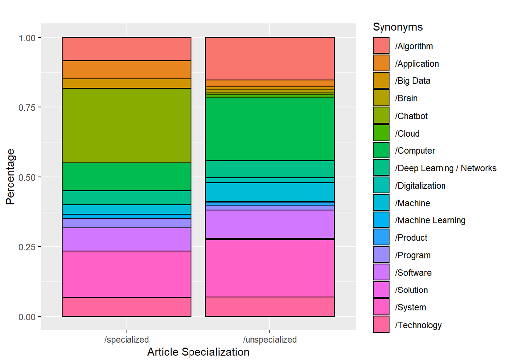

```r
ggplot(specialization_synonyms[c(1:12,24:40),], aes(fill=Synonyms, y=Count, x=Article_Specialization)) +
    geom_bar(position="fill", stat="identity", color="black") +
    labs(title = "",
         y = "Percentage",
         x = "Article Specialization")
```

The term “Computer” is significantly more often used in unspecialized articles, while the term “Chatbot” is far more prominent in specialized articles. Other notable differences can be seen in the terms “Algorithm”, “Machine” and “Application”, with the former two more often used in unspecialized articles and the latter more often in specialized articles. “Software” and “System” do not appear substantially more in unspecialized articles than in specialized articles. For the remaining synonyms, there are no clear tendencies distinguishable.

## author expertise and percentage of synonyms

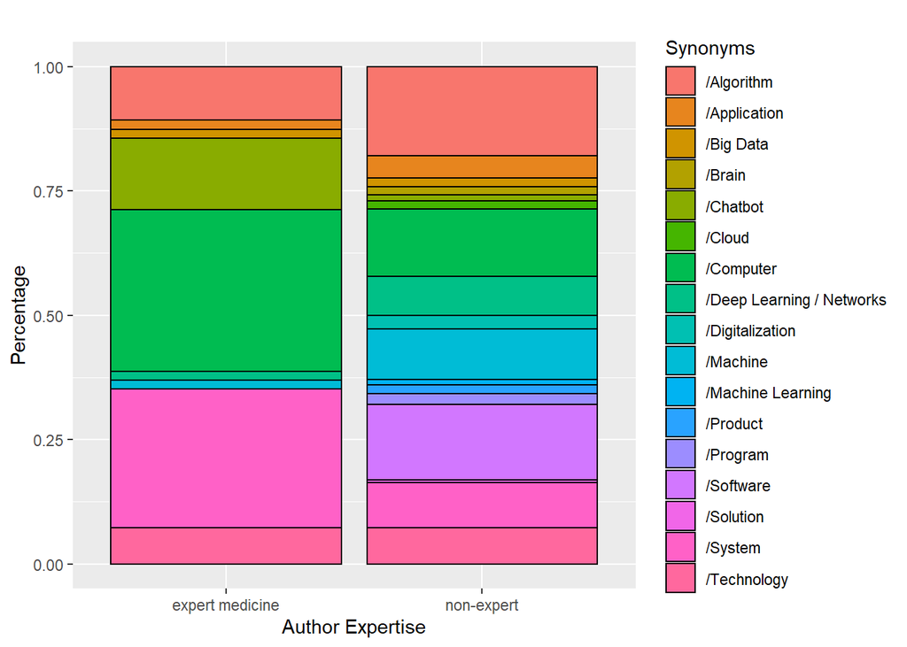

```r
ggplot(expert_synonyms, aes(fill=Synonyms, y=Count, x=Author)) +
    geom_bar(position="fill", stat="identity", color = "black") +
    labs(title = "",
         y = "Percentage",
         x = "Author Expertise")
```

## year and count of synonyms

```r
# combine year and synonym data
year_synonyms <- rbind(year_data, synonym_data)
year_synonyms
```

|  | Tags | Total | 1 | 2 | 3 | 4 | 5 | 6 | 7 | 8 | 9 | 10 | 11 | 12 | 13 | 14 | 15 | 16 | 17 | 18 | 19 | 20 | 21 | 22 | 23 | 24 |
| --- | --- | --- | --- | --- | --- | --- | --- | --- | --- | --- | --- | --- | --- | --- | --- | --- | --- | --- | --- | --- | --- | --- | --- | --- | --- | --- |
| 1 | /2017 | 3 | NA | NA | NA | NA | NA | NA | NA | NA | NA | NA | NA | NA | NA | NA | NA | NA | 1 | 1 | NA | NA | NA | NA | 1 | NA |
| 2 | /2018 | 4 | NA | NA | NA | NA | NA | NA | NA | NA | NA | 1 | NA | 1 | NA | NA | NA | 1 | NA | NA | NA | 1 | NA | NA | NA | NA |
| 3 | /2019 | 8 | NA | 1 | NA | NA | NA | NA | NA | 1 | 1 | NA | NA | NA | 1 | NA | 1 | NA | NA | NA | NA | NA | 1 | 1 | NA | 1 |
| 4 | /2020 | 9 | 1 | NA | 1 | 1 | 1 | 1 | 1 | NA | NA | NA | 1 | NA | NA | 1 | NA | NA | NA | NA | 1 | NA | NA | NA | NA | NA |
| 5 | /Algorithm | 48 | 9 | 2 | 1 | NA | 9 | NA | 6 | NA | NA | NA | NA | NA | NA | NA | 1 | NA | 4 | NA | NA | 1 | NA | 7 | NA | 8 |
| 6 | /Application | 11 | NA | NA | 1 | NA | NA | NA | NA | 2 | NA | NA | NA | NA | NA | 1 | NA | NA | NA | 1 | NA | 2 | NA | 4 | NA | NA |
| 7 | /Big Data | 5 | NA | NA | NA | NA | 2 | NA | NA | NA | NA | NA | NA | 1 | NA | NA | NA | NA | NA | NA | NA | 2 | NA | NA | NA | NA |
| 8 | /Brain | 3 | NA | NA | 3 | NA | NA | NA | NA | NA | NA | NA | NA | NA | NA | NA | NA | NA | NA | NA | NA | NA | NA | NA | NA | NA |
| 9 | /Chatbot | 18 | NA | NA | NA | NA | NA | NA | NA | NA | NA | NA | NA | 2 | NA | NA | NA | NA | NA | NA | NA | 16 | NA | NA | NA | NA |
| 10 | /Cloud | 3 | NA | NA | 2 | NA | 1 | NA | NA | NA | NA | NA | NA | NA | NA | NA | NA | NA | NA | NA | NA | NA | NA | NA | NA | NA |

[output cut: 11 more lines]

```r
# summarize articles and counts
year_synonyms <- year_synonyms %>%
  pivot_longer(3:26, names_to = "article", values_to = "count") %>%
  drop_na()
year_synonyms
```

| Tags | Total | article | count |
| --- | --- | --- | --- |
| /2017 | 3 | 17 | 1 |
| /2017 | 3 | 18 | 1 |
| /2017 | 3 | 23 | 1 |
| /2018 | 4 | 10 | 1 |
| /2018 | 4 | 12 | 1 |
| /2018 | 4 | 16 | 1 |
| /2018 | 4 | 20 | 1 |
| /2019 | 8 | 2 | 1 |
| /2019 | 8 | 8 | 1 |
| /2019 | 8 | 9 | 1 |

[output cut: 118 more lines]

```r
syn <- year_synonyms[25:128,]
year <- year_synonyms[1:24,]

# merge data based on the articles
year_synonyms <- merge.data.frame(syn[-2],year[-2],by="article") %>%
                            select(c(2,3,4)) %>%
                            group_by(Tags.x, Tags.y) %>%
                            summarise_each(list(sum = sum)) %>%
                            rename("Synonyms" = 1, "Year" = 2, "Count" = 3)
year_synonyms
```

| Synonyms | Year | Count |
| --- | --- | --- |
| /Algorithm | /2017 | 4 |
| /Algorithm | /2018 | 1 |
| /Algorithm | /2019 | 18 |
| /Algorithm | /2020 | 25 |
| /Application | /2017 | 1 |
| /Application | /2018 | 2 |
| /Application | /2019 | 6 |
| /Application | /2020 | 2 |
| /Big Data | /2018 | 3 |
| /Big Data | /2020 | 2 |

[output cut: 33 more lines]

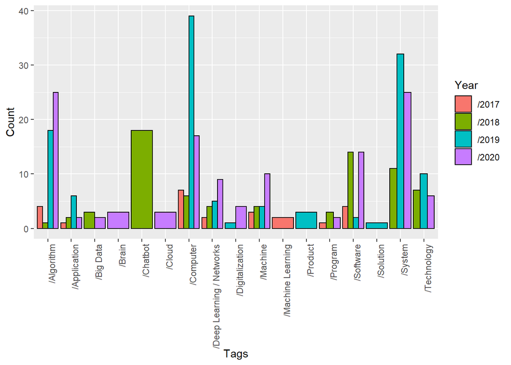

```r
ggplot(year_synonyms, aes(fill=Year, y=Count, x=Synonyms)) +
    geom_bar(position="dodge", stat="identity", color = "black") +
    labs(x = "Tags") +
    theme(axis.text.x=element_text(angle=90,hjust=1))
```

Interestingly, the terms “Algorithm”, “Application”, “Computer”, “Deep Learning / Neural Networks”, “Machine” and “Software” are used at least once per year. “Algorithm” is strikingly more often used in articles written in 2019 and 2020 than in earlier articles, with a peak in 2020. Similarly, “Computer” shows also a clear popularity in 2019 and 2020, but instead with an evident peak in 2019. The only clear linear rise in utilization can be seen for “Deep Learning / Neural Networks”, with a more rapid rise in 2020. Comparably, the term “Machine” gains in significance over the years, again with a rapid rise in 2020. In contrast to that, the usage of “Software” is not as linear, with a clear favoritism in 2018 and 2020. A last remarkable observation can be made for the synonym “System”, which is only used in articles written in 2018 and later, with noticeably more mentions in 2019 and 2020.

## personal impression and percentage of synonyms

```r
# combine personal impression and synonym data
impression_synonyms <- rbind(personal_impression_data, synonym_data)
impression_synonyms
```

|  | Tags | Total | 1 | 2 | 3 | 4 | 5 | 6 | 7 | 8 | 9 | 10 | 11 | 12 | 13 | 14 | 15 | 16 | 17 | 18 | 19 | 20 | 21 | 22 | 23 | 24 |
| --- | --- | --- | --- | --- | --- | --- | --- | --- | --- | --- | --- | --- | --- | --- | --- | --- | --- | --- | --- | --- | --- | --- | --- | --- | --- | --- |
| 33 | /positive | 13 | NA | 1 | NA | NA | NA | 1 | NA | 1 | NA | NA | 1 | 1 | 1 | 1 | 1 | 1 | 1 | NA | 1 | 1 | NA | NA | 1 | NA |
| 29 | /neither positive nor negative | 8 | NA | NA | 1 | 1 | 1 | NA | 1 | NA | 1 | NA | NA | NA | NA | NA | NA | NA | NA | 1 | NA | NA | 1 | 1 | NA | NA |
| 28 | /negative | 3 | 1 | NA | NA | NA | NA | NA | NA | NA | NA | 1 | NA | NA | NA | NA | NA | NA | NA | NA | NA | NA | NA | NA | NA | 1 |
| 5 | /Algorithm | 48 | 9 | 2 | 1 | NA | 9 | NA | 6 | NA | NA | NA | NA | NA | NA | NA | 1 | NA | 4 | NA | NA | 1 | NA | 7 | NA | 8 |
| 6 | /Application | 11 | NA | NA | 1 | NA | NA | NA | NA | 2 | NA | NA | NA | NA | NA | 1 | NA | NA | NA | 1 | NA | 2 | NA | 4 | NA | NA |
| 7 | /Big Data | 5 | NA | NA | NA | NA | 2 | NA | NA | NA | NA | NA | NA | 1 | NA | NA | NA | NA | NA | NA | NA | 2 | NA | NA | NA | NA |
| 8 | /Brain | 3 | NA | NA | 3 | NA | NA | NA | NA | NA | NA | NA | NA | NA | NA | NA | NA | NA | NA | NA | NA | NA | NA | NA | NA | NA |
| 9 | /Chatbot | 18 | NA | NA | NA | NA | NA | NA | NA | NA | NA | NA | NA | 2 | NA | NA | NA | NA | NA | NA | NA | 16 | NA | NA | NA | NA |
| 10 | /Cloud | 3 | NA | NA | 2 | NA | 1 | NA | NA | NA | NA | NA | NA | NA | NA | NA | NA | NA | NA | NA | NA | NA | NA | NA | NA | NA |
| 12 | /Computer | 69 | NA | 8 | NA | NA | 10 | 3 | 3 | NA | 1 | 3 | 1 | 3 | NA | NA | 9 | NA | 6 | NA | NA | NA | 1 | 1 | 1 | 19 |

[output cut: 10 more lines]

```r
# summarize articles and counts
impression_synonyms <- impression_synonyms %>%
  pivot_longer(3:26, names_to = "article", values_to = "count") %>%
  drop_na()
impression_synonyms
```

| Tags | Total | article | count |
| --- | --- | --- | --- |
| /positive | 13 | 2 | 1 |
| /positive | 13 | 6 | 1 |
| /positive | 13 | 8 | 1 |
| /positive | 13 | 11 | 1 |
| /positive | 13 | 12 | 1 |
| /positive | 13 | 13 | 1 |
| /positive | 13 | 14 | 1 |
| /positive | 13 | 15 | 1 |
| /positive | 13 | 16 | 1 |
| /positive | 13 | 17 | 1 |

[output cut: 118 more lines]

```r
impr <- impression_synonyms[c(1:24),]
syn <- impression_synonyms[25:128,]

# merge data based on the articles
impression_synonyms<- merge.data.frame(impr[-2],syn[-2],by="article") %>%
                            select(c(2,4,5)) %>%
                            group_by(Tags.x, Tags.y) %>%
                            summarise_each(list(sum = sum)) %>%
                            rename("Personal_Impression" = 1, "Synonyms" = 2, "Count" = 3)
impression_synonyms
```

| Personal_Impression | Synonyms | Count |
| --- | --- | --- |
| /negative | /Algorithm | 17 |
| /negative | /Computer | 22 |
| /negative | /Deep Learning / Networks | 9 |
| /negative | /Machine | 2 |
| /negative | /Program | 3 |
| /negative | /Software | 14 |
| /negative | /System | 7 |
| /negative | /Technology | 2 |
| /neither positive nor negative | /Algorithm | 23 |
| /neither positive nor negative | /Application | 6 |

[output cut: 27 more lines]

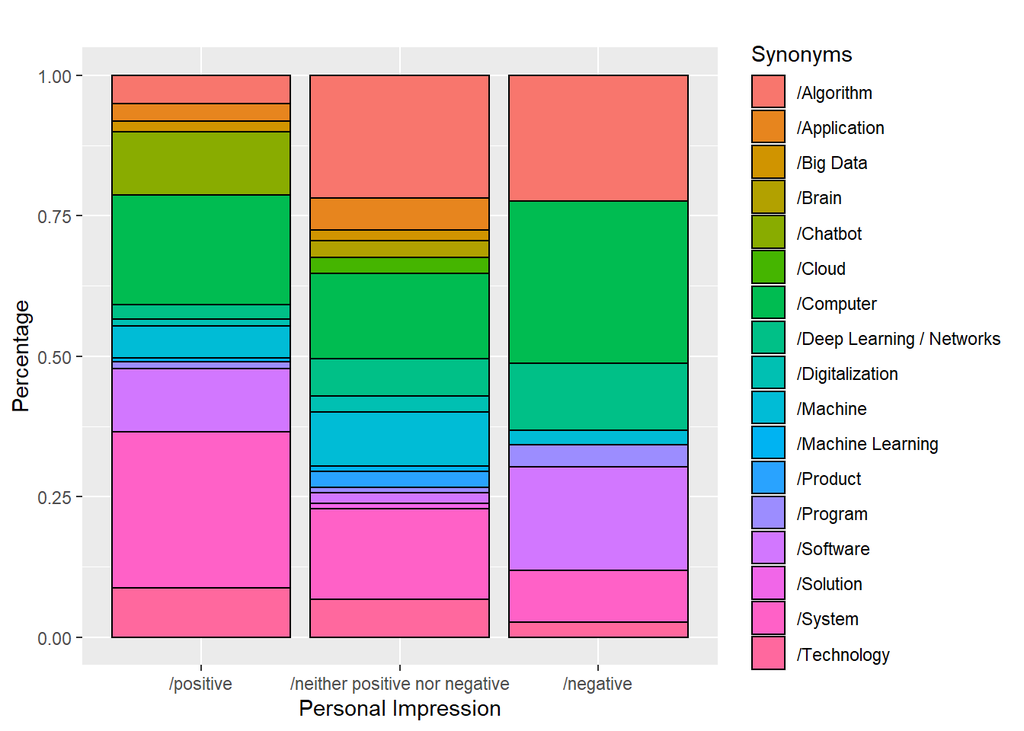

```r
ggplot(impression_synonyms, aes(fill=Synonyms, y=Count, x=factor(Personal_Impression,levels=c("/positive","/neither positive nor negative","/negative")))) +
    geom_bar(position="fill", stat="identity", color = "black") +
    labs(title = "",
         y = "Percentage",
         x = "Personal Impression")
```

In the articles we perceive as positive, the most often used synonyms are “System”, “Software”, “Computer” and “Chatbot”. Interestingly, the articles containing “Chatbot” seem exclusively positive to us. Those (to us) conveying a rather neutral attitude towards the application of AI in medicine most often include the synonyms “System”, “Machine”, “Computer” and “Algorithm”, all four nearly equally often. A remarkable observation is also that these articles contain more various synonyms than the positive and negative ones. The articles that we perceive as negative integrate the least amount of synonyms, with “Software”, “Deep Learning / Neural Networks”, “Computer” and “Algorithm” building the majority. A notable fact is that the usage of “Algorithm” seems to lead us to perceive the respective articles as rather neutral or negative instead of positive.

# illnesses

## illnesses total

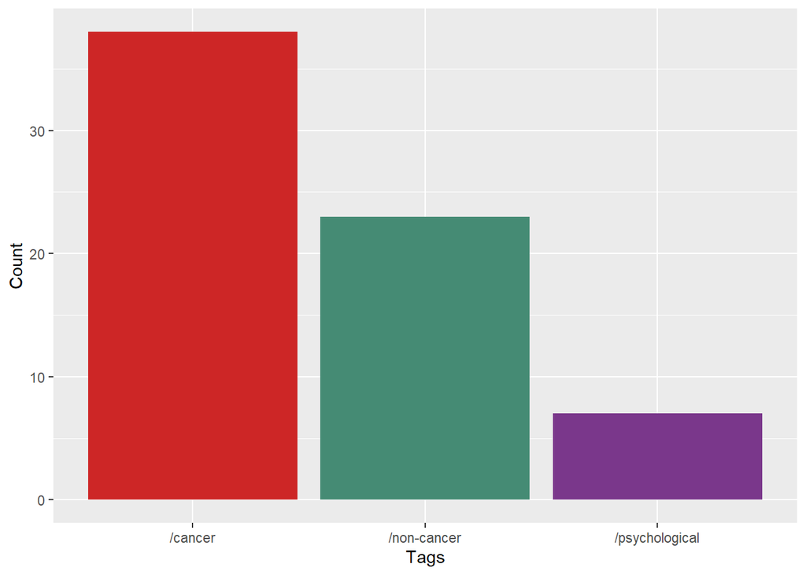

```r
ggplot(illness_data, aes(fill=Tags, y=Total, x=Tags)) +
    geom_bar(position="dodge", stat="identity") +
    labs(y = "Count", x = "Tags") +
    theme(legend.position = "none") +
    scale_fill_manual(values=c("firebrick3","aquamarine4","mediumorchid4"))
```

Various forms of cancer are the mostly discussed applications of AI, while also applications for non-cancer illnesses like eye diseases are addressed. Psychological illnesses like schizophrenia are the least often mentioned ones that AI can be used for.

## year and percentage of illnesses

```r
# combine year and illness data
year_illness <- rbind(year_data, illness_data)
year_illness
```

|  | Tags | Total | 1 | 2 | 3 | 4 | 5 | 6 | 7 | 8 | 9 | 10 | 11 | 12 | 13 | 14 | 15 | 16 | 17 | 18 | 19 | 20 | 21 | 22 | 23 | 24 |
| --- | --- | --- | --- | --- | --- | --- | --- | --- | --- | --- | --- | --- | --- | --- | --- | --- | --- | --- | --- | --- | --- | --- | --- | --- | --- | --- |
| 1 | /2017 | 3 | NA | NA | NA | NA | NA | NA | NA | NA | NA | NA | NA | NA | NA | NA | NA | NA | 1 | 1 | NA | NA | NA | NA | 1 | NA |
| 2 | /2018 | 4 | NA | NA | NA | NA | NA | NA | NA | NA | NA | 1 | NA | 1 | NA | NA | NA | 1 | NA | NA | NA | 1 | NA | NA | NA | NA |
| 3 | /2019 | 8 | NA | 1 | NA | NA | NA | NA | NA | 1 | 1 | NA | NA | NA | 1 | NA | 1 | NA | NA | NA | NA | NA | 1 | 1 | NA | 1 |
| 4 | /2020 | 9 | 1 | NA | 1 | 1 | 1 | 1 | 1 | NA | NA | NA | 1 | NA | NA | 1 | NA | NA | NA | NA | 1 | NA | NA | NA | NA | NA |
| 25 | /cancer | 38 | 2 | 2 | NA | NA | 4 | 1 | 2 | NA | 1 | 2 | 4 | 2 | NA | 1 | 6 | 1 | 4 | NA | 1 | NA | 1 | 2 | 1 | 1 |
| 31 | /non-cancer | 23 | 1 | NA | NA | 1 | 1 | 1 | 1 | NA | 3 | 1 | NA | 4 | NA | NA | NA | NA | NA | NA | NA | 1 | 1 | 4 | 3 | 1 |
| 35 | /psychological | 7 | NA | NA | NA | NA | NA | 1 | NA | NA | NA | NA | NA | 1 | 1 | NA | NA | NA | NA | 3 | NA | 1 | NA | NA | NA | NA |

```r
# summarize articles and counts
year_illness <- year_illness %>%
  pivot_longer(3:26, names_to = "article", values_to = "count") %>%
  drop_na()
year_illness
```

| Tags | Total | article | count |
| --- | --- | --- | --- |
| /2017 | 3 | 17 | 1 |
| /2017 | 3 | 18 | 1 |
| /2017 | 3 | 23 | 1 |
| /2018 | 4 | 10 | 1 |
| /2018 | 4 | 12 | 1 |
| /2018 | 4 | 16 | 1 |
| /2018 | 4 | 20 | 1 |
| /2019 | 8 | 2 | 1 |
| /2019 | 8 | 8 | 1 |
| /2019 | 8 | 9 | 1 |

[output cut: 50 more lines]

```r
illn <- year_illness[25:60,]
year <- year_illness[1:24,]

# merge data based on the articles
year_illness <- merge.data.frame(illn[-2],year[-2],by="article") %>%
                            select(c(2,3,4)) %>%
                            group_by(Tags.x, Tags.y) %>%
                            summarise_each(list(sum = sum)) %>%
                            rename("Illness" = 1, "Year" = 2, "Count" = 3)
year_illness
```

| Illness | Year | Count |
| --- | --- | --- |
| /cancer | /2017 | 5 |
| /cancer | /2018 | 5 |
| /cancer | /2019 | 13 |
| /cancer | /2020 | 15 |
| /non-cancer | /2017 | 3 |
| /non-cancer | /2018 | 6 |
| /non-cancer | /2019 | 9 |
| /non-cancer | /2020 | 5 |
| /psychological | /2017 | 3 |
| /psychological | /2018 | 2 |

[output cut: 2 more lines]

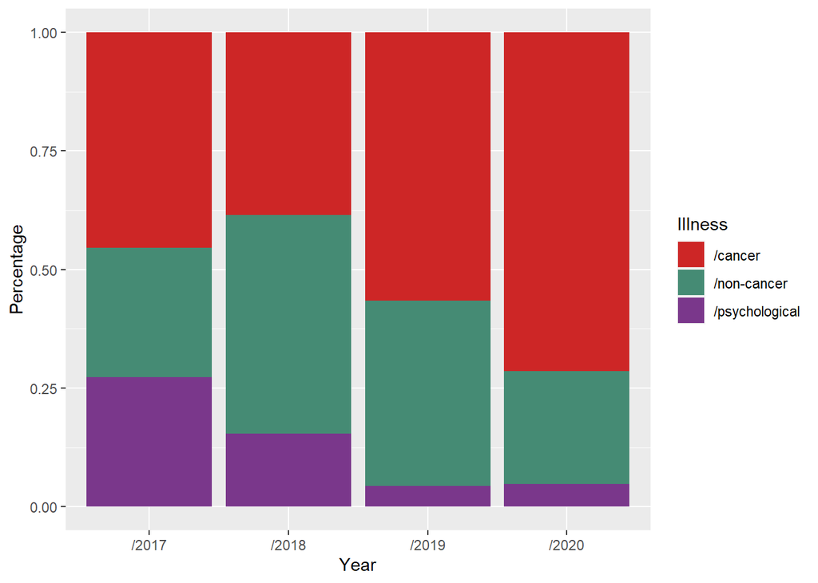

```r
ggplot(year_illness, aes(fill=Illness, y=Count, x=Year)) +
    geom_bar(position="fill", stat="identity") +
    labs(y = "Percentage") +
    scale_fill_manual(values=c("firebrick3","aquamarine4","mediumorchid4"))
```

The mentions of AI applications for psychological illnesses show a rapid linear decrease over the years, while applications for cancer seem to gain in importance.

## sentiment and illnesses

```r
# combine illness and sentiment data
illness_sentiment <- rbind(illness_data, sentiment_data)
illness_sentiment
```

|  | Tags | Total | 1 | 2 | 3 | 4 | 5 | 6 | 7 | 8 | 9 | 10 | 11 | 12 | 13 | 14 | 15 | 16 | 17 | 18 | 19 | 20 | 21 | 22 | 23 | 24 |
| --- | --- | --- | --- | --- | --- | --- | --- | --- | --- | --- | --- | --- | --- | --- | --- | --- | --- | --- | --- | --- | --- | --- | --- | --- | --- | --- |
| 25 | /cancer | 38 | 2 | 2 | NA | NA | 4 | 1 | 2 | NA | 1 | 2 | 4 | 2 | NA | 1 | 6 | 1 | 4 | NA | 1 | NA | 1 | 2 | 1 | 1 |
| 31 | /non-cancer | 23 | 1 | NA | NA | 1 | 1 | 1 | 1 | NA | 3 | 1 | NA | 4 | NA | NA | NA | NA | NA | NA | NA | 1 | 1 | 4 | 3 | 1 |
| 35 | /psychological | 7 | NA | NA | NA | NA | NA | 1 | NA | NA | NA | NA | NA | 1 | 1 | NA | NA | NA | NA | 3 | NA | 1 | NA | NA | NA | NA |
| 34 | /pro AI | 126 | NA | 7 | 6 | NA | 4 | 11 | 4 | 9 | 1 | 3 | 10 | 7 | 2 | 3 | 7 | 2 | 4 | 4 | 7 | 11 | 4 | 14 | 2 | 4 |
| 30 | /neutral | 78 | 1 | 7 | 1 | 1 | 2 | NA | 6 | 3 | 1 | 4 | 6 | 3 | 4 | 5 | NA | NA | NA | NA | 4 | 13 | 2 | 10 | 1 | 4 |
| 26 | /contra AI | 35 | 3 | 2 | NA | NA | 2 | NA | 1 | 1 | 1 | 3 | 1 | 1 | NA | NA | 1 | NA | NA | NA | 1 | 3 | NA | 3 | NA | 12 |

```r
# summarize articles and counts
illness_sentiment <- illness_sentiment %>%
  pivot_longer(3:26, names_to = "article", values_to = "count") %>%
  drop_na()
illness_sentiment
```

| Tags | Total | article | count |
| --- | --- | --- | --- |
| /cancer | 38 | 1 | 2 |
| /cancer | 38 | 2 | 2 |
| /cancer | 38 | 5 | 4 |
| /cancer | 38 | 6 | 1 |
| /cancer | 38 | 7 | 2 |
| /cancer | 38 | 9 | 1 |
| /cancer | 38 | 10 | 2 |
| /cancer | 38 | 11 | 4 |
| /cancer | 38 | 12 | 2 |
| /cancer | 38 | 14 | 1 |

[output cut: 81 more lines]

```r
illn <- illness_sentiment[1:36,]
sentim <- illness_sentiment[37:91,]

# merge data based on the articles
illness_sentiment <- merge.data.frame(illn[-2],sentim[-2],by="article") %>%
                            select(c(2,4,5)) %>%
                            group_by(Tags.x, Tags.y) %>%
                            summarise_each(list(sum = sum)) %>%
                            rename("Illness" = 1, "Sentiment" = 2, "Count" = 3)
illness_sentiment
```

| Illness | Sentiment | Count |
| --- | --- | --- |
| /cancer | /contra AI | 31 |
| /cancer | /neutral | 56 |
| /cancer | /pro AI | 94 |
| /non-cancer | /contra AI | 29 |
| /non-cancer | /neutral | 48 |
| /non-cancer | /pro AI | 65 |
| /psychological | /contra AI | 4 |
| /psychological | /neutral | 20 |
| /psychological | /pro AI | 35 |

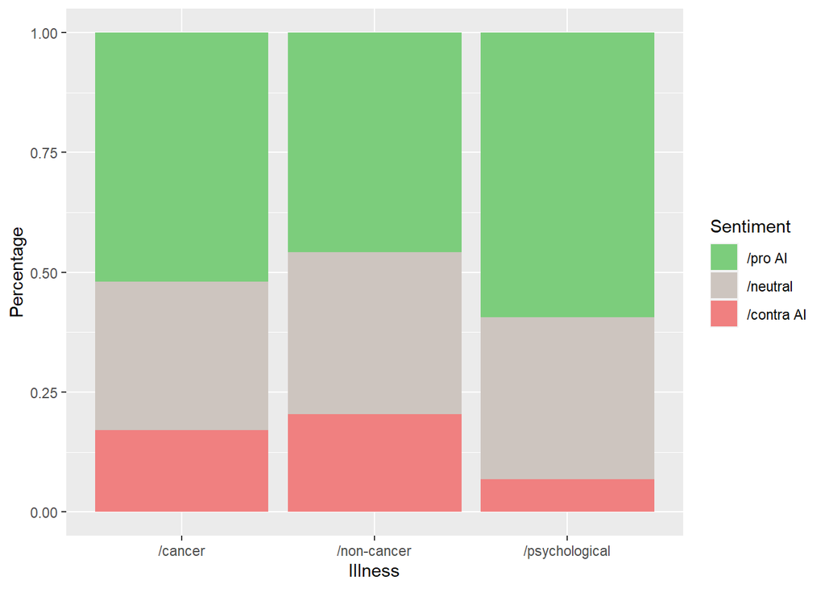

```r
ggplot(illness_sentiment, aes(fill=factor(Sentiment,levels=c("/pro AI","/neutral","/contra AI")), y=Count, x=Illness)) +
    geom_bar(position="fill", stat="identity") +
    labs(y = "Percentage",
         fill = "Sentiment") +
    scale_fill_manual(values=c("palegreen3","seashell3","lightcoral"))
```

The only striking difference that can be made out here is that psychological applications are less often connected to negative sentiments. The rest seems rather consistent across all illnesses.

## personal impression and illnesses

```r
# combine illness and personal impression data
illness_impression <- rbind(illness_data, personal_impression_data)
illness_impression
```

|  | Tags | Total | 1 | 2 | 3 | 4 | 5 | 6 | 7 | 8 | 9 | 10 | 11 | 12 | 13 | 14 | 15 | 16 | 17 | 18 | 19 | 20 | 21 | 22 | 23 | 24 |
| --- | --- | --- | --- | --- | --- | --- | --- | --- | --- | --- | --- | --- | --- | --- | --- | --- | --- | --- | --- | --- | --- | --- | --- | --- | --- | --- |
| 25 | /cancer | 38 | 2 | 2 | NA | NA | 4 | 1 | 2 | NA | 1 | 2 | 4 | 2 | NA | 1 | 6 | 1 | 4 | NA | 1 | NA | 1 | 2 | 1 | 1 |
| 31 | /non-cancer | 23 | 1 | NA | NA | 1 | 1 | 1 | 1 | NA | 3 | 1 | NA | 4 | NA | NA | NA | NA | NA | NA | NA | 1 | 1 | 4 | 3 | 1 |
| 35 | /psychological | 7 | NA | NA | NA | NA | NA | 1 | NA | NA | NA | NA | NA | 1 | 1 | NA | NA | NA | NA | 3 | NA | 1 | NA | NA | NA | NA |
| 33 | /positive | 13 | NA | 1 | NA | NA | NA | 1 | NA | 1 | NA | NA | 1 | 1 | 1 | 1 | 1 | 1 | 1 | NA | 1 | 1 | NA | NA | 1 | NA |
| 29 | /neither positive nor negative | 8 | NA | NA | 1 | 1 | 1 | NA | 1 | NA | 1 | NA | NA | NA | NA | NA | NA | NA | NA | 1 | NA | NA | 1 | 1 | NA | NA |
| 28 | /negative | 3 | 1 | NA | NA | NA | NA | NA | NA | NA | NA | 1 | NA | NA | NA | NA | NA | NA | NA | NA | NA | NA | NA | NA | NA | 1 |

```r
# summarize articles and counts
illness_impression <- illness_impression %>%
  pivot_longer(3:26, names_to = "article", values_to = "count") %>%
  drop_na()
illness_impression
```

| Tags | Total | article | count |
| --- | --- | --- | --- |
| /cancer | 38 | 1 | 2 |
| /cancer | 38 | 2 | 2 |
| /cancer | 38 | 5 | 4 |
| /cancer | 38 | 6 | 1 |
| /cancer | 38 | 7 | 2 |
| /cancer | 38 | 9 | 1 |
| /cancer | 38 | 10 | 2 |
| /cancer | 38 | 11 | 4 |
| /cancer | 38 | 12 | 2 |
| /cancer | 38 | 14 | 1 |

[output cut: 50 more lines]

```r
illn <- illness_impression[1:36,]
impr <- illness_impression[37:60,]

# merge data based on the articles
illness_impression <- merge.data.frame(illn[-2],impr[-2],by="article") %>%
                            select(c(2,3,4)) %>%
                            group_by(Tags.x, Tags.y) %>%
                            summarise_each(list(sum = sum)) %>%
                            rename("Illness" = 1, "Impression" = 2, "Count" = 3)
illness_impression
```

| Illness | Impression | Count |
| --- | --- | --- |
| /cancer | /negative | 5 |
| /cancer | /neither positive nor negative | 10 |
| /cancer | /positive | 23 |
| /non-cancer | /negative | 3 |
| /non-cancer | /neither positive nor negative | 11 |
| /non-cancer | /positive | 9 |
| /psychological | /neither positive nor negative | 3 |
| /psychological | /positive | 4 |

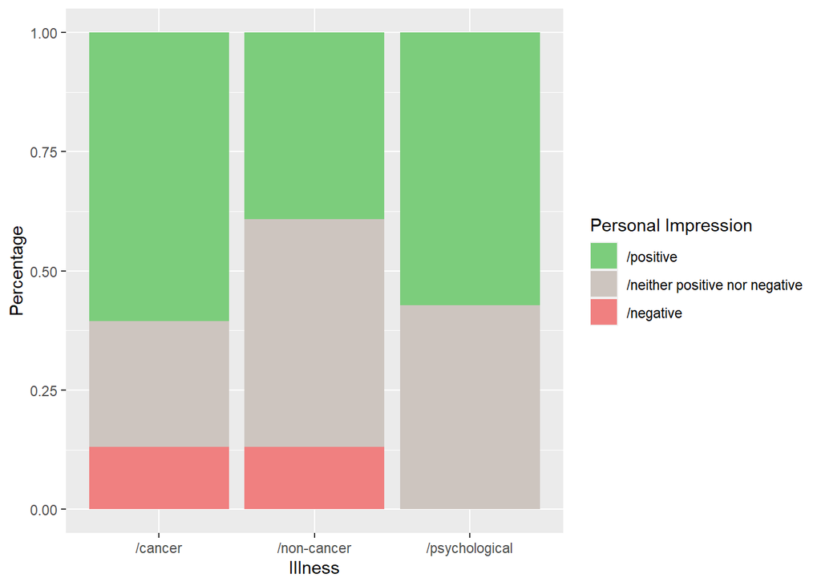

```r
ggplot(illness_impression, aes(fill=factor(Impression,levels=c("/positive","/neither positive nor negative","/negative")), y=Count, x=Illness)) +
    geom_bar(position="fill", stat="identity") +
    labs(y = "Percentage",
         fill = "Personal Impression") +
    scale_fill_manual(values=c("palegreen3","seashell3","lightcoral"))
```

We perceive articles discussing AI applications for psychological illnesses as either positive or neutral towards AI (with no clear tendency), but not as negative. Cancer related articles seem most often in favor of AI, while non-cancer related articles more often seem neither in favor nor against AI applications.

## SWOT and illnesses

```r
# combine illness and SWOT data
illness_SWOT <- rbind(illness_data, SWOT_data)
illness_SWOT
```

|  | Tags | Total | 1 | 2 | 3 | 4 | 5 | 6 | 7 | 8 | 9 | 10 | 11 | 12 | 13 | 14 | 15 | 16 | 17 | 18 | 19 | 20 | 21 | 22 | 23 | 24 |
| --- | --- | --- | --- | --- | --- | --- | --- | --- | --- | --- | --- | --- | --- | --- | --- | --- | --- | --- | --- | --- | --- | --- | --- | --- | --- | --- |
| 25 | /cancer | 38 | 2 | 2 | NA | NA | 4 | 1 | 2 | NA | 1 | 2 | 4 | 2 | NA | 1 | 6 | 1 | 4 | NA | 1 | NA | 1 | 2 | 1 | 1 |
| 31 | /non-cancer | 23 | 1 | NA | NA | 1 | 1 | 1 | 1 | NA | 3 | 1 | NA | 4 | NA | NA | NA | NA | NA | NA | NA | 1 | 1 | 4 | 3 | 1 |
| 35 | /psychological | 7 | NA | NA | NA | NA | NA | 1 | NA | NA | NA | NA | NA | 1 | 1 | NA | NA | NA | NA | 3 | NA | 1 | NA | NA | NA | NA |
| 39 | /strength | 59 | NA | 1 | 2 | NA | 2 | 4 | 3 | 3 | 2 | 1 | 4 | 8 | NA | 1 | 2 | 3 | 3 | NA | 2 | 1 | 2 | 10 | 3 | 2 |
| 44 | /weakness | 60 | 2 | 5 | 1 | 1 | 3 | NA | 6 | 2 | 1 | 3 | 4 | NA | NA | 2 | 5 | NA | NA | NA | 5 | 2 | 2 | 4 | 2 | 10 |
| 32 | /opportunity | 112 | NA | 2 | 6 | 1 | 7 | 2 | 5 | 6 | 2 | 3 | 6 | 7 | 2 | 6 | 8 | NA | 3 | 2 | 9 | 10 | 9 | 14 | 1 | 1 |
| 40 | /threat | 26 | 1 | 1 | 3 | NA | 5 | NA | NA | 3 | NA | 1 | 1 | NA | NA | 2 | 2 | NA | NA | NA | NA | 2 | NA | 2 | 1 | 2 |

```r
# summarize articles and counts
illness_SWOT <- illness_SWOT %>%
  pivot_longer(3:26, names_to = "article", values_to = "count") %>%
  drop_na()
illness_SWOT
```

| Tags | Total | article | count |
| --- | --- | --- | --- |
| /cancer | 38 | 1 | 2 |
| /cancer | 38 | 2 | 2 |
| /cancer | 38 | 5 | 4 |
| /cancer | 38 | 6 | 1 |
| /cancer | 38 | 7 | 2 |
| /cancer | 38 | 9 | 1 |
| /cancer | 38 | 10 | 2 |
| /cancer | 38 | 11 | 4 |
| /cancer | 38 | 12 | 2 |
| /cancer | 38 | 14 | 1 |

[output cut: 99 more lines]

```r
illn <- illness_SWOT[1:36,]
swot <- illness_SWOT[37:109,]

# merge data based on the articles
illness_SWOT <- merge.data.frame(illn[-2],swot[-2],by="article") %>%
                            select(c(2,4,5)) %>%
                            group_by(Tags.x, Tags.y) %>%
                            summarise_each(list(sum = sum)) %>%
                            rename("Illness" = 1, "SWOT" = 2, "Count" = 3)
illness_SWOT
```

| Illness | SWOT | Count |
| --- | --- | --- |
| /cancer | /opportunity | 85 |
| /cancer | /strength | 53 |
| /cancer | /threat | 18 |
| /cancer | /weakness | 54 |
| /non-cancer | /opportunity | 62 |
| /non-cancer | /strength | 38 |
| /non-cancer | /threat | 14 |
| /non-cancer | /weakness | 36 |
| /psychological | /opportunity | 23 |
| /psychological | /strength | 13 |

[output cut: 2 more lines]

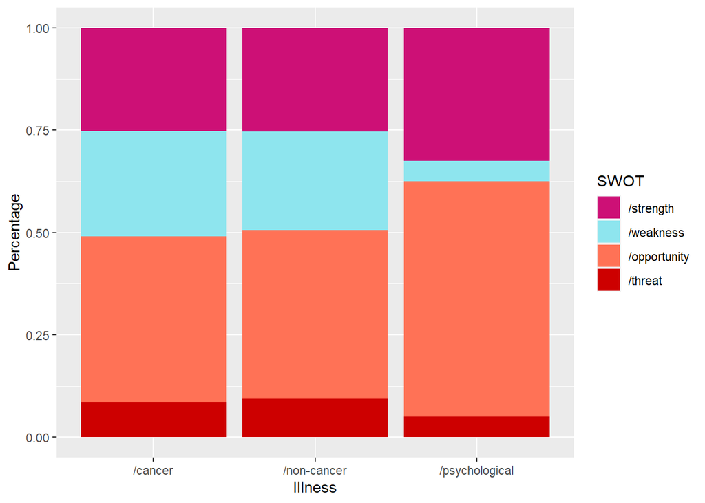

```r
ggplot(illness_SWOT, aes(fill=factor(SWOT, levels=c("/strength","/weakness","/opportunity","/threat")), y=Count, x=Illness)) +
    geom_bar(position="fill", stat="identity") +
    labs(y = "Percentage",
         fill = "SWOT") +
    scale_fill_manual(values=c("deeppink3","cadetblue2","coral1","red3"))
```

Interestingly, the distribution of the discussed SWOTs is nearly identical for cancer and non-cancer applications of AI, while the mentioned opportunities and strengths clearly outweigh the weaknesses and threats of applications for psychological illnesses.